# Aquatic invertebrates

Andrew Pawley

## 1. Introduction

This chapter deals with invertebrates that are aquatic or semi-aquatic, such as crustaceans, molluscs, echinoderms, sea-worms, jellyfish and corals.[^1] It addresses the following questions: (1) What terms for aquatic invertebrates can be attributed to Proto Oceanic (POc) and other high-order interstages of Oceanic? (2) What uses were made of these animals? (3) How does the number of taxa reconstructable for POc compare with the number attested in well-described contemporary languages?

The marine invertebrate fauna of the tropical southwest and central Pacific is fairly uniform, so that when Oceanic speakers first dispersed across this region some 3000 years ago they generally encountered familiar creatures. It must be added that not every island or island group has the full range of habitats: fringing coral reefs, mangrove forests, estuarine mudflats, seagrass flats, etc.

Molluscs, crustaceans and echinoderms gathered in and around the intertidal zone form one of the most reliable protein food sources of coastal Oceanic communities. The bulk of foraging for invertebrates in this zone is done by women while in most societies diving for lobsters and deep water molluscs is mainly men’s work. Mollusc shells were traditionally made into a variety of tools and ornaments. Archaeological discoveries underline the longstanding importance of water invertebrates to speakers of Oceanic languages. Living sites and middens left by bearers of the Lapita culture contain extensive remains of molluscs and crustaceans and artefacts made from mollusc shells (see §4.1).

Linguistic evidence that foraging on the reef for invertebrates was important to Proto Oceanic speakers is found in two widespread cognate sets noted by Clark (1991). Clark’s POc reconstructions are given below, with a few additional cognates.[^2] The first is a verb.

| **POc** |  | *paŋoda | ‘gather seafood on the reef’ (Clark 1991) |
| --- | --- | --- | --- |
| PT | Gapapaiwa | *vanota* | ‘net prawns’ |
| PT | Motu | *haoda* | ‘to fish’ |
| MM | Teop | *vagana* | (1) ‘gather marine organisms on the reef’; (2) ‘to fish, go fishing’ |
| SES | Bugotu | *vaŋoda* | ‘hunt for shellfish on the reef’[^3] |
| SES | Gela | *vaŋoda* | [V] ‘collect food on the reef.’; [N] ‘shellfish, crustaceans and echinoderms gathered on the reef’ |
| SES | Sa’a | *haŋoda* | ‘Haliotis, abalone’ |
| NCV | Mota | *vaŋona* | ‘catch fish with a line, get shell-fish, etc. for a relish’ |
| NCV | Nguna | *(pa)vaŋoda* | ‘look for shellfish, gather shells, fish for seafish’ |
| NCV | Southeast Ambrym | *pœŋor* | ‘to fish’ |
| NCV | Namakir | *(ba)vaŋot* | ‘forage on reef’ |
| NCV | Lonwolwol | *foŋōr* | ‘look for fish’ |
| NCV | Uripiv | *(e)vaŋor* | ‘forage on the reef’ |
| SV | Anejom̃ | *(a)haŋec* | ‘forage on reef’ |
| Mic | Marshallese | *yaŋʷeɹ* | ‘go fishing’ |
| Fij | Rotuman | *haŋota* | [v] ‘to fish.’; [N] ‘fishing excursion, shoal of fish’ |
| Pn | Tongan | *fāŋota* | ‘to fish, or to search for shell-fish or any kind of *fiŋota*’ |
| Pn | Niuean | *faŋota* | ‘gather shellfish on the reef’ |
| Pn | Rennellese | *hāŋota* | ‘to fish or gather shells, especially by women on the reef’ |
| Pn | Ifira-Mele | *fāŋota* | ‘gather shellfish etc. on the reef’ |

| **POc** |  | *p⟨in⟩aŋoda, *piŋoda | ‘seafood gathered on the reef, edible sea invertebrates’ (Clark 1991) |
| --- | --- | --- | --- |
| PT | Molima | *igoda* | ‘collect shellfish’ |
| PT | Kilivila | *vigoda* | ‘shell (clams, snails)’ |
| PT | Dobu | *igoda* | [v] ‘gather shellfish’; [N] ‘shellfish’ |
| MM | Tolai | *vinaŋonoi* | ‘generic name for sea shells’ (final syllable irregular) |
| NCV | Nguna | *vinaŋoda* | ‘shell, shellfish’ |
| Pn | Tongan | *fiŋota* | ‘sea creature of any kind other than vertebrates: shell-fish, crustaceans, cuttle-fish, jellyfish, eels, sea-snakes, sea-slugs, starfish, etc. and even sea-weeds’ |
| Pn | Niuean | *fiŋota* | (1) ‘shellfish’; (2) ‘gather shellfish’ (McEwen); ‘an edible sea crab’ (Sperlich) |
| Pn | Samoan | *fīŋota* | ‘general term for edible molluscs and invertebrate sea animals’ |
| Pn | Takuu | *fīnota* | ‘various kinds of shell-fish and seafoods gathered by women’ |

## 2. Classification of marine invertebrates

### 2.1. Zoological classification

In the discussion that follows cognate sets presented will be grouped under standard zoological categories. Zoology offers a complex phylogenetic taxonomy of invertebrates based on current views of their evolutionary relationships and morphological characters. The invertebrate family tree distinguishes more than 20 levels of grouping from kingdom down to species. Here we need only note those distinctions which will be useful in organising the material from Oceanic languages.

| phylum | class | (sub)order | tribe |
| --- | --- | --- | --- |
| ARTHROPODA |  |  |  |
|  | Crustacea |  |  |
|  |  | Decapoda |  |
|  |  |  | Palinura and Astacura: crayfish, lobsters, slipper lobsters |
|  |  |  | Anomura: hermit crabs, coconut crabs, mangrove lobster, etc. |
|  |  |  | Brachyura: true crabs |
|  |  | Natantia: true prawns and shrimps |  |
|  |  | Stomatopoda: Mantis shrimps, etc. |  |
|  |  | Thoracia: barnacles |  |
|  |  | shrimp-like animals |  |
| MOLLUSCA |  |  |  |
|  |  | Gastropoda: univalves or snail-like shellfish |  |
|  |  | Bivalvia (Pelecypoda): bivalves or clam-like shellfish |  |
|  |  | Cephalopoda: octopus, squid, nautilus |  |
|  |  | Amphineura: chitons |  |
| ECHINODERMATA |  |  |  |
|  | Echinoidea: sea eggs (sea urchins) |  |  |
|  | Asteroidea: starfish |  |  |
|  | Ophiuroidea: brittle starfish |  |  |
|  | Holothuroidea: sea cucumbers (bêche de mer, trepang, holothurians) |  |  |
|  | Crinoidea: sea lilies and feather stars |  |  |
| CNIDARIA (COELENTERATA) |  |  |  |
|  | Anthozoa: corals, anemones |  |  |
|  | Scyphozoa: true jellyfish |  |  |
|  | Hydrozoa: fire corals, hydroids, siphonophores |  |  |
|  | Ctenophora: comb jellyfish |  |  |
| WORM-LIKE: annelids, nemerteans, acanthoceaphalans |  |  |  |
| PORIPHERA: sponges |  |  |  |

### 2.2. Oceanic folk taxonomies of aquatic invertebrates

In order to get an idea of the likely size and taxonomic structure of the POc lexicon for aquatic invertebrates one must look at contemporary languages whose speakers exploit a marine and shore environment fairly similar to that inhabited by POc speakers. Unfortunately there are very few systematic studies in this domain. There is a fairly detailed account of aquatic invertebrate taxonomy in Wayan, a dialect of the Western Fijian language (Pawley 1994, Pawley and Sayaba 2003) spoken on two small islands on the western margin of Fiji. Wayan speakers distinguish by name more than 240 marine invertebrate taxa.[^4] Almost 150 of these names apply to molluscs, about 48 to crustaceans, about 31 to echinoderms, about 12 to coelenterates and about five to marine worms.

Folk classifications of animals have many fewer levels than those recognised by zoologists. Berlin (1992) has discussed at length the organising principles underlying folk taxonomies of animals and plants (see chapter 8 for more detail). As folk taxonomies go, the Wayan classification of aquatic animals is among the more complex. Some domains have a depth of six contrasting levels - two levels more than Berlin’s model recognises as the known maximum for folk taxonomies of wild animals.

Table 4.1 shows the contrasts between some first-order categories of invertebrates that occur in the Wayan Fijian taxonomy. These fall under no higher category other than *manumanu*, which refers to all creatures.

In many respects Wayan higher-order taxa differ markedly from those found in zoological classifications. For instance, there is no echinoderm category: sea cucumbers, sea urchins, starfish and brittle starfish are each assigned to separate primary taxa. There is no category corresponding to crustaceans. There is a general name for sea cucumbers but no overt taxon uniting the various sea urchin taxa (these animals represent a covert category, which Wayans readily identify by a descriptive phrase such as *manumanu laulau ni ðakau* ‘spiky animals of the reef’). Unsurprisingly, octopus and squid form a primary taxon apart from other molluscs. There is a generic for gastropods (*ðiði*) but no generic for all bivalves. Instead there are generics for burrowing bivalves (*tavē*) and all kinds of oysters (*ðiva*). Wayan also has a category, *manumanu gwāgwā*, that refers to edible decapods, subsuming *ura*, *seka*, *tubā*, *uŋa* and *tolā*. However, this is a ‘collective’ category rather than a true superordinate taxon: one does not point to an animal and identify it as a *manumanu gwāgwā*.

**Table 4.1** Some high-order aquatic invertebrate taxa in Wayan

| 1. | *manumanu* | ‘animals, creatures’ |
| --- | --- | --- |
| 2. | *ura* | prawns & lobsters |
|  | *seka* | aquatic crabs |
|  | *tubā* | land crabs |
|  | *uŋa* | hermit crabs, coconut crabs |
|  | *ðiði* | gastropods |
|  | *tavē* | burrowing bivalves |
|  | *ðiva* | oysters |
|  | *sulua* | octopus & squid |
|  | *drī* | sea cucumbers |
|  | [covert] | sea urchins |
|  | *ikali ni ikō* | starfish |
|  | *sulua vadravadra* | brittle starfish |
|  | *baya ni waitaði* | sea worms |
|  | *bōsuðu* | sea slugs |
|  | *drālevu* | sea hares |
|  | *dromani* | anemones |
|  | *lase* | hard corals |
|  | *sam* | jellyfish |

Systematic descriptions of other Oceanic taxonomies are admittedly few but the available evidence suggests that the size and taxonomic structure of the Wayan terminology are fairly typical of Oceanic-speaking maritime communities.[^5] It is reasonable to assume that the POc taxonomy was roughly of the same order.

## 3. Crustaceans

### 3.1. Order *Decapoda*: crabs, lobsters, prawns

The crustaceans named and taken for food and bait in Oceanic societies are almost exclusively decapods. There is a well established PMP generic for prawns and crayfish, which is continued in POc.

| **PAn** |  | *qudaŋ | ‘shrimp, lobster’ (Blust 2002) |
| --- | --- | --- | --- |
| **POc** |  | *quraŋ | ‘generic for prawns and shrimps, crayfish and lobsters’ |
| NNG | Manam | *uro* | ‘crayfish’ |
| PT | Dobu | *ʔula(boʔa)* | ‘lobster, medium sized’ |
| PT | Motu | *ura* | ‘crayfish’ |
| MM | Nalik | *uraŋ* | ‘crayfish’ |
| SES | Gela | *ura* | ‘generic for crayfish, *Panulirus* spp.’ |
| SES | ’Are’are | *ura* | ‘shrimp, crayfish, prawn’ |
| SES | Arosi | *ura* | ‘a small prawn’ |
| SES | Sa’a | *ura* | ‘crayfish, prawn’ |
| NCV | Mota | *ura* | ‘crayfish’ |
| NCV | Raga | *ura* | ‘generic for crayfish’ |
| NCV | Namakir | *ʔira* | ‘crayfish, shrimp’ |
| NCV | Sakao | *uraŋ* | ‘crayfish’ |
| Mic | Kiribatese | *ura* | ‘lobster’ |
| NCal | Nemi | *kula* | ‘prawn’ |
| Fij | Bauan | *ura* | ‘generic for prawns and crayfish’ |
| Fij | Wayan | *ura* | ‘generic for prawns and shrimps, and in extended sense also for lobsters (*urau*)’ |
| **PPn** |  | *qura | ‘crayfish’ (pollex) |
| Pn | Tongan | *ʔuo* | ‘generic for crayfish and prawns’ |
| Pn | Samoan | *ula* | ‘crayfish’ |
| Pn | Samoan | *ula-tai* | ‘a saltwater shrimp’ |
| Pn | Samoan | *ula-a-vai* | ‘a freshwater shrimp’ |

### 3.2. Palinura: spiny lobsters

The Palinura are represented in Oceania by two major families: (1) Palinuridae, spiny or rock lobsters and (2) Scyllaridae, slipper or shovel-nosed lobsters. (The terms ‘lobster’ and ‘crayfish’ are used interchangeably by many English speakers and the gloss ‘crayfish’ is commonly found in the dictionaries and wordlists.)

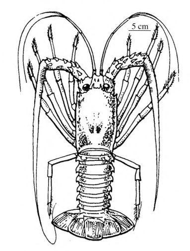

**Figure 4.1:** *Palinurus* sp., spiny lobster

#### 3.2.1. Palinuridae, spiny lobsters

Lobsters are prized food in the Oceanic world. Among the spiny lobsters the commonest species is *Palinurus pencillatus*, the common spiny lobster. *Palinurus versicolor* is a larger, more colourful relative. These are distinguished as specifics in Wayan.

In contemporary languages reflexes of the POc generic *quraŋ (see §3.1) are typically applied to spiny lobsters (*Palinurus* spp.) as opposed to the very distinctive slipper lobsters (Scyllaridae). It is likely that this was also the case in POc.

#### 3.2.2. Scyllaridae, slipper (or shovel-nosed) lobsters

Slipper lobsters are a family of clawless decapods with a very distinctive appearance, having a broad flat carapace and enlarged antennae projecting forward from the head as wide plates. Species of this family are found in warm waters throughout Oceania. A term for slipper lobster can be tentatively reconstructed for POc but the comparisons are phonologically problematic.

| **POc** |  | *[pa]paba | ‘*Parribacus* sp. (Scyllaridae), slipper lobster’ |
| --- | --- | --- | --- |
| PT | Misima | *sapapa* | ‘k.o. saltwater lobster, lacking long feelers’ (*p > *s* irregular) |
| MM | Tolai | *papaba* | ‘crayfish sp.’ |
| SES | Gela | *mapa* | ‘slipper lobster’ (perhaps dissimilation: *p > *m*, for †*v) |
| NCV | Mwotlap | *na-vam* | ‘slipper lobster, *Parribacus caledonicus*’ |
| NCV | Mota | *vavapa* | ‘kind of crawfish’ |
| NCV | Uripiv | *ne-vep* | ‘slipper lobster, *Parribacus caledonicus*’ |
| NCV | Naman | *ne-vev* | ‘slipper lobster, *Parribacus caledonicus*’ |
| NCV | Unua | *nepep* | ‘slipper lobster, *Parribacus caledonicus*’ |
| NCV | South Efate | *pepep* | ‘slipper lobster, *Parribacus caledonicus*’ |
| NCal | Iaai | *(wa)hep* | ‘slipper lobster’ (*p > *h*, for †*v) |

There is a well attested term in PCP which shows some resemblance to the above. However, the correspondence of PPn *t to Fijian *ð* indicates a PCP palatal (which Blust (1978b) writes *c and Geraghty 1986 as *j).

| **PCP** |  | *jabajaba | ‘*Parribacus* sp. (Scyllaridae), slipper lobster’ |
| --- | --- | --- | --- |
| Fij | Wayan | *ðabaðaba* | ‘*Parribacus* sp., similar to Moreton Bay Bug’ |
| **PPn** |  | *tapatapa | ‘Moreton Bay Bug’ (pollex) |
| Pn | East Futunan | *tapatapa* | ‘Moreton Bay Bug’ |
| Pn | Kapingamarangi | *tapatapa* | ‘*Parribacus antartica*, sand lobster’ |
| Pn | Nukuoro | *tapatapa* | ‘slipper lobster’ |
| Pn | Tikopia | *tapatapa* | ‘large edible prawn (unidentified), up to 20 cm’ |

cf. also:

| NNG | Gedaged | *sabai* | ‘shrimp, prawn, freshwater crayfish’ (*sabai dumadum* ‘small marine crayfish, up to 12 inches long’) |
| --- | --- | --- | --- |
| SV | Kwamera | *təpatəpa* | ‘slipper lobster, *Parribacus caledonicus*’ (probably a loan from Polynesian) |

Another set of resemblant forms, represented in certain MM languages of New Georgia and Santa Isabel and in one SES language, shows a superficial resemblance to the Central Pacific forms but the sound correspondences do not match and point instead to an earlier form such as *pepete or *tepe-tepe).

| MM | Roviana | *pepete* | ‘a crustacean resembling *Ibacus ciliatus*’ |
| --- | --- | --- | --- |
| MM | Marovo | *pepete* | ‘shovel-nosed lobster’ |
| MM | Nduke | *epete* | ‘shovel-nosed lobster, *Thenus* or *Ibacus* sp.’ |
| MM | Maringe | *pʰapate* | ‘edible saltwater crustacean, crayfish-like’ |
| SES | Ghari | *tepe-tepe* | ‘small crayfish of reef’ (metathesis?) |

### 3.3. Suborder Natantia: true prawns and shrimps

In many Oceanic languages reflexes of *guraŋ serve as the general name for prawns and shrimps and this was evidently the case in POc. However, a second term, *luRa, has reflexes in certain Micronesian and Fijian languages.

| **PROc** |  | *luRa | ‘small shrimp’ (Geraghty 1990: PEOc) |
| --- | --- | --- | --- |
| Mic | Ponapean | *lūr* | ‘a small shrimp’ |
| Mic | Mokilese | *lūr* | ‘a small shrimp’ |
| Fij | (many dialects) | *lua* | ‘a small shrimp’ |

cf. also:

| NNG | Sengseng | *e-lus* | ‘freshwater shrimp’ |
| --- | --- | --- | --- |

### 3.4. Suborder Anomura: hermit crabs, mud lobsters, half-crabs

The Anomura, which include hermit and coconut crabs, are not true crabs but form a suborder that is sister to true crabs (Brachyura). They have a long abdomen and appear to have only three pairs of walking legs, the last pair usually being hidden inside the gill chamber under the carapace. The Anomura are an extremely varied group and no Oceanic language has a name for the group as a whole.

#### 3.4.1. Paguroidea: Coenobitidae (hermit and coconut crabs), and Diogenidae and Paguridae (sea-dwelling hermit crabs)

This group includes the familiar hermit crabs which carry a gastropod shell to protect their long soft abdomen. The coenobitids are terrestrial hermit crabs which have the left claw larger than or equal to the right. The coenobitids include the large coconut crab (or robber crab). The pagurids have a larger right claw. The sea-dwelling hermit crabs of the families Diogenidae and Paguridae are considerably larger than land-dwelling hermit crabs, growing up to 7 to 10 cm in length.

#### 3.4.2. *Birgus latro*, coconut crab

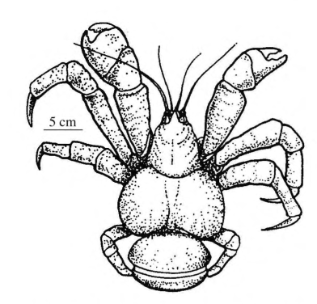

**Figure 4.2:** *Birgus latro*, coconut crab

There is a strongly supported reconstruction for the coconut crab, *Birgus latro*, which climbs coconut trees to sever coconuts and is widely believed by Oceanic comunities to be able to open coconuts. This very large crab is considered a delicacy and has been hunted to extinction on some smaller islands.

| **PMP** |  | *qayuyu | ‘coconut crab, *Birgus latro*’ (Blust 2002) |
| --- | --- | --- | --- |
| **POc** |  | *qayuyu | ‘coconut crab, *Birgus latro*’ (Blust 1972b) |
| Yap | Yapese | *ʔayūy* |  |
| Adm | Mussau | *aiu* |  |
| Adm | Titan | *kasusu* |  |
| Adm | Wuvulu | *aruru* | (Blust 1996b: 20) |
| PT | Dobu | *ʔayuyu* |  |
| SES | Tolo | *ui* |  |
| SES | Lau | *kasukasu* | (*q > *k* irregular) |
| SES | Sa’a | *esusu* |  |
| SES | Arosi | *asusu* |  |
| SES | Bauro | *aū* |  |
| NCV | Lonwolwol | *au* | ‘small sand crab that runs into the sea at one’s approach’ |
| NCV | South Efate | *as* | (John Lynch, pers. comm.; *y > *s/*u* is regular) |
| NCal | Iaai | *eu* |  |
| Fij | Rotuman | *aruru* |  |
| **PPn** |  | *qūqū | ‘coconut crab, *Birgus latro*’ (pollex) |
| Pn | Tongan | *ʔūʔū* |  |
| Pn | East Futunan | *ʔūʔū* |  |
| Pn | Tikopia | *ū* |  |
| Pn | Kapingamarangi | *ū* |  |

POc *qayuyu was replaced in PMic by *afafi (Bender et al. 2003:12).

#### 3.4.3. Hermit crabs

A number of Oceanic languages distinguish several kinds of hermit crabs by name. The distinguishing criteria include size, habitat (sea vs land) and growth stage. For example, for Niuean Sperlich (1997) records four taxa of hermit crab: *āo* ‘hermit crab, *Dardanus* sp.’, *pulou* ‘a hermit crab’, *uŋa-mea* ‘a land dwelling hermit crab’ and *uŋa-uŋa* ‘a sea dwelling hermit crab’. Hermit crabs are widely used as bait.

Three uninominal terms for hermit crabs are attributable to POc: *qumʷaŋ, *koba and *kato(q)u. It is unlikely that these terms were full synonyms. Unfortunately, the glosses provided for the reflexes in our sources are typically general and do not allow a semantic distinction to be made between the three POc terms.

*qumʷaŋ continues a PAn etymon. In Oceanic languages a reflex of this form commonly stands as a generic for typical hermit crabs, in contrast to coconut crabs. However, in several Oceanic languages reflexes have an extended sense that includes coconut crabs.

| **PAn** |  | *qumaŋ | ‘hermit crab’ (Blust 1980b) |
| --- | --- | --- | --- |
| **POc** |  | *qumʷaŋ | (1) ‘generic for hermit crabs’; (2) ‘generic for hermit and coconut crabs’ (?) |
| NNG | Gedaged | *(wa)gum* | ‘hermit crab’ |
| NNG | Manam | *guma* | ‘hermit crab’ |
| NNG | Numbami | *gubaŋa* | ‘hermit crab’ |
| NNG | Takia | *gum* | ‘hermit crab’ |
| PT | Dobu | *gumana* | ‘hermit crab’ |
| PT | Molima | *gumana* | ‘hermit crab’ |
| PT | Gapapaiwa | *gumaɣa* | ‘hermit crab’ |
| PT | Misima | *go-gaman* | ‘hermit crab’ |
| MM | Tolai | *quman* | ‘hermit crab, *Paguridae* sp.’ |
| MM | Tabar | *guma* | ‘hermit crab’ |
| NCV | Paamese | *o-umo* | ‘crab (generic)’ |
| SV | Anejom̃ | *n-umwan* | ‘k.o. small hermit-crab’ (*-n* unexplained) |
| NCal | Pije | *kumʷa* | ‘*Coenobita* sp.’ |
| Fij | Bauan | *uŋa* | ‘hermit crab’ |
| Fij | Wayan | *uŋa* | (1) ‘hermit crab’; (2) ‘generic for hermit and coconut crabs’ |
| Fij | Wayan | *uŋa tolou* | ‘generic for hermit crabs’ |
| Fij | Wayan | *uŋa vule* | ‘coconut crab’ |
| **PPn** |  | *quŋa | ‘generic for hermit crab’ (pollex gives ‘hermit crab sp.’) |
| Pn | Tongan | *ʔuŋa* | ‘large hermit crab’ |
| Pn | Niuean | *uŋa* | ‘coconut crab, *Birgus latro*’ |
| Pn | Niuean | *uŋa-mea* | ‘land-dwelling hermit crab’ |
| Pn | Niuean | *uŋa-uŋa* | ‘sea-dwelling hermit crab’ |
| Pn | Samoan | *uŋa* | ‘name given to hermit crabs in general’ |
| Pn | Tikopia | *uŋa* | ‘hermit crab’ |
| Pn | Rennellese | *ʔuŋa* | ‘hermit crab, *Coenobita* sp.’ |
| Pn | Rennellese | *ʔuŋa mouku* | ‘forest-dwelling hermit crabs’ |
| Pn | Rennellese | *ʔuŋa pūŋou* | ‘sea-dwelling hermit crab carrying the *puŋou* parasite’ |

A second term, *koba, is less widely attested but reflexes are found in the Admiralties, Meso-Melanesian (in Northwest Solomonic) and Southeast Solomonic.

| **POc** |  | *koba | ‘hermit crab’ |
| --- | --- | --- | --- |
| Adm | Penchal | *(kai)kop* | ‘hermit crab’ |
| MM | Marovo | *koba* | ‘generic for hermit crabs’ |
| MM | Nduke | *koba* | ‘generic for hermit crabs’ |
| SES | Gela | *koba* | ‘generic for hermit crabs’ |
| SES | Ghari | *koba, ko-koba* | ‘hermit crab’ |
| SES | Tolo | *ko-koba* | ‘hermit crab’ |

A third term has reflexes in Mussau, Southeast Solomonic and North-Central Vanuatu.

| **POc** |  | *kato(q)u | ‘hermit crab’ |
| --- | --- | --- | --- |
| Adm | Mussau | *kitou* |  |
| SES | Arosi | *kawou, kou* | ‘hermit crab, *Coenobita* spp.’ |
| SES | Bauro | *gou* |  |
| **PNCV** |  | *kato(q)u | ‘hermit crab’ (Clark 2009 gives *katou) |
| NCV | Mota | *gatou* |  |
| NCV | Raga | *gatou* |  |
| NCV | Tamambo | *hatou* |  |
| NCV | Nguna | *katou* |  |
| NCV | Namakir | *katoʔ* |  |

#### 3.4.4. Other Anomura: Thalassina, mud lobsters, and Porcellanidae, porcelain crabs (half-crabs)

There are only two species of *Thalassina*, the distinctive ‘mud lobster’ of the Indo-Pacific region, a nocturnal animal that digs a deep and intricate network of burrows in mangrove mudflats. It typically grows up to 16-20 cm long. *Thalassina* are found as far east as Fiji and Samoa. The meat is bland and this animal is not a prized source of food but it is trapped for its edible claws in parts of Fiji. In the few dictionaries that provide names for the mud lobster each language has its own generic, e.g. Gedaged *gumei*, Nduke *zona*, Roviana *zoa*, Bauan Fijian *manā*, Western Fijian *tolā*, No POc reconstruction is possible.

Porcelain crabs (or half-crabs) are small, usually 1-2 cm wide. They are common on rocky beaches and shorelines. Names for porcelain crabs are seldom given in Oceanic dictionaries and no widespread cognate set has been found.

### 3.5. Brachyura: true crabs

True crabs are the dominant decapods on marine coasts. In true crabs (tribe Brachyura) the front pair of legs are clawed and the abdomen is reduced, flattened and folded underneath the carapace. Eggs are attached to the pleopods of the female’s abdomen. Of the many crab species only a minority are of economic value to Oceanic communities.

Oceanic speaking communities exploiting reefs and mangrove swamps typically distinguish between 20 and 30 crab taxa, excluding crabs of the tribe Anomura. For example, dictionaries of Arosi, Wayan Fijian and Niuean, list about 30, 33 and 22 taxa, respectively, excluding the Anomura. There is little doubt that POc would have had a similar array. However, only seven secure POc terms for Brachyura crabs have been reconstructed: *kape, *kaRaka, *kaRu(i)ki, *kuka, *rakum(u), *qalimaŋo, *tubaRa.

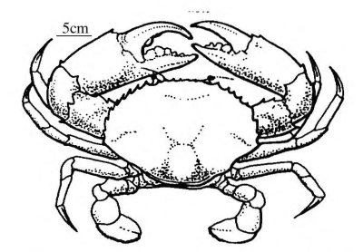

**Figure 4.3:** *Scylla serrata*, mangrove crab

#### 3.5.1. Portunidae, mangrove and swimming crabs

Oceania has many species of portunids, belonging to the genera *Portunus*, *Thalamita* and *Charybdis*. Most are large crabs, much valued as food. The English folk names ‘mud crab’, ‘mangrove crab’ or ‘black crab’ are often applied to *Scylla serrata*, a large round crab which may exceed 20 cm in width and which burrows in muddy shallow tidal waters of estuaries and mangrove swamps. POc continues a PMP term, *qalimaŋaw, that probably denoted several portunids of the genus *Scylla*. Wolff’s dictionary of Cebuano describes *alimaŋu* as ‘edible crab of tidal swamps, round in shape, up to 10 inches in diameter, black on back, white front, large meaty claws’, unmistakeably a large *Scylla* sp.

| **PMP** |  | *qalimaŋaw | ‘mangrove crab’ (Blust 1980b) |
| --- | --- | --- | --- |
| **POc** |  | *qalimaŋo | ‘large mangrove crab, *Scylla serrata* (Portunidae) and probably other portunids’ |
| NNG | Kove | *alimaŋo* | ‘mangrove crab’ |
| PT | Molima | *kalimana* | ‘mangrove crab’ |
| PT | Dobu | *kalimana* | ‘large black crab’ |
| PT | Dobu | *ʔalimana* | ‘large black crab’ |
| PT | Kilivila | *keimagu* | ‘large mud crab’ |
| MM | Teop | *animano* | ‘k.o. swamp crab’ |
| SES | Lau | *alimaŋo* | ‘largest sp. of crab, found on outer reef, black’ |
| SES | ’Are’are | *alimano* | ‘big crab living in mangrove swamps’ |
| SES | Arosi | *arimaŋo* | ‘very large crab with paddles, found in mangrove swamps’ |
| SES | To’aba’ita | *alimaŋo* | ‘mangrove crab’ |
| Mic | Ponapean | *elimoŋ* | ‘mangrove crab’ |
| Mic | Carolinian | *alimoŋ* | ‘large sea crab with red-orange shell’ |
| Mic | Puluwatese | *yelimoŋ* | ‘a seacrab smaller than mangrove crab’ |
| Mic | Trukese | *ɔ̄nimɔŋ* | ‘mangrove crab’ |
| Fij | Rotuman | *ʔɔimɔnu* | ‘k.o. crab’ |
| Pn | Samoan | *(paʔa)limaŋo* | ‘large edible mud crab, *Scylla* sp.’ (*paʔa* ‘generic for crabs’) |

#### 3.5.2. *Cardisoma* spp. and other large land crabs

The large land crabs, *Cardisoma* spp., are an important food source in many Oceanic communities and there are often several terms referring to their growth stages and spawning behaviour. For example, Foale (1998) reports that in West Gela (central Solomons) females of the abundant land crab *Cardisoma hirtipes* migrate to the beach at certain phases in the lunar cycle in the wet season, from October to December, releasing zoea larvae from their egg mass (*lami*). This is known as the *sau lami* (wash eggs). Three weeks before doing this they migrate to the sea to immerse themselves, an event known as the *sapa toga* (thousands go seawards). This is the preferred time to take them because they are fatter. In Fiji, Wayans refer to the mass migration of *Cardisoma hirtipes* as *vui*.

| **POc** |  | *tubaRa | ‘probably generic for large land crabs, *Cardisoma* spp.’ (cf. Geraghty 1990) |
| --- | --- | --- | --- |
| PT | Motu | *dubara* | ‘small land-crab’ |
| MM | Tolai | *tubara* | ‘land-crab’ |
| SES | Gela | *tumbala* | ‘*Cardisoma carnifex*, white land crab’ |
| SES | ’Are’are | *opara* | ‘k.o. crab’ |
| NCV | Mota | *tipara* | ‘k.o. land crab’ |
| SV | Sye | *tupo* | ‘a large land crab’ |
| SV | Kwamera | *tupʷa* | ‘k.o. landcrab’ |
| Fij | Rotuman | *fupa* | ‘land crab’ |
| Fij | Wayan | *tubā* | ‘generic for large land crabs, esp. Cardisoma’ |
| **PPn** |  | *tupa | ‘landcrab’ (pollex) |
| Pn | Samoan | *tupa* | ‘land crab sp. with large claws’ |
| Pn | Tongan | *tupa* | ‘k.o. land crab’ |
| Pn | Tikopia | *tupa* | ‘large land crab, keenly sought for food’ |
| Pn | Rarotongan | *tupa* | ‘*Cardisoma cardifax*, edible land crab’ |

cf. also:

| MM | Nduke | *tubavu* | ‘*Cardisoma* sp., probably *Cardisoma hirtipes*’ |
| --- | --- | --- | --- |
| SES | Ghari | *tubā* | ‘a species of land crab’ (for †*tubala*) |

| **POc** |  | *rakum(u) | ‘k.o. large crab, probably a land crab’ |
| --- | --- | --- | --- |
| Adm | Lou | *roum* | ‘k.o. crab’ |
| NNG | Manam | *rakum* | ‘k.o. big, red crab’ |
| NNG | Mangap | *rukum* | ‘general name for crabs’ |
| PT | Dobu | *lakua* | ‘generic for crabs’ (loss of *m irregular) |
| PT | Kilivila | *lakum* | ‘small mud crab’ |
| PT | Muyuw | *lakum* | ‘crab’ |
| PT | Gapapaiwa | *rakum* | ‘k.o. crab’ |
| MM | Tabar | *raku* | ‘crab’ |
| MM | Roviana | *garumu* | ‘*Cardisoma carnifex*, white land crab’ (metath.) |
| SES | Bugotu | *ragomu* | ‘a crab’ |
| NCV | Southeast Ambrym | *oum* | ‘land crab’ |
| NCV | Namakir | *rakumʷ* | ‘land crab’ |
| NCV | Neve’ei | *nu-rukʰum* | ‘a crab’ |
| SV | Sye | *a-roɣum* | ‘k.o. crab’ |
| SV | Anejom̃ | *n-raɣ* | ‘k.o. crab’ |
| Mic | Ponapean | *rokumʷ* | ‘sp. of small land crab’ |
| Mic | Puluwatese | *rɔ̄kum* | ‘large land crab’ |
| Mic | Puluwatese | *rɔ̄kum(ihœt)* | ‘common black sea crabs’ |
| Mic | Woleaian | *ẓaxumʷu* | ‘crab (generic)’ |

cf. also:

| NNG | Kove | *laumu* | ‘k.o. crab, said to be western dialect for sand crab, called *karoki* in eastern dialect’ |
| --- | --- | --- | --- |

#### 3.5.3. Grapsidae, (1) shore crabs, (2) burrowing crabs of mud flats

The most commonly seen shore crabs are the grapsids, which forage among rocks and coral rubble in the intertidal zone. The carapace is squarish, with very convex edges. The last pair of legs are not flattened but are adapted for climbing over rocks. There are several genera, including *Grapsus*, *Sesarma*, *Metopograpsus*, and *Leptograpsus*. Oceanic languages typically distinguish several grapsid taxa. For example, Wayan distinguishes two main taxa within the Grapsidae: mangrove crabs (*Sesarma* spp., *Metopograpsus* spp.), which are *kuka*, and shore (or rock) crabs (*Grapsus* spp.), which are *galau*, as well as dividing the generics *kuka* and *galau* into further subtaxa.

#### 3.5.4. *Sesarma* spp., mangrove grapsids

Judging by its reflexes in EOc languages POc *kuka referred chiefly to grapsids of the genus *Sesarma*, which live in mangrove forest mudflats. In Tolai (MM), Arosi and To’aba’ita (SES) and Lonwolwol (NCV) the reflex has become a generic term for crabs.

| **POc** |  | *kuka | ‘mudcrab, including *Sesarma* sp. or spp., living in mangrove forest and mudflats’ |
| --- | --- | --- | --- |
| MM | Tolai | *kuka* | ‘generic for crabs’ |
| MM | Maringe | *kokʰa* | ‘hermit crab’ |
| MM | Sursurunga | *kuk* | ‘crab’ |
| SES | Arosi | *kuka* | ‘generic term for crabs, excluding the Anomura and possibly portunids’ |
| SES | To’aba’ita | *ʔuʔa* | ‘general term for a variety of crabs, excluding hermit crabs and cocout crabs’ (syn. *ŋuda*) |
| SES | Lau | *ūa* | ‘a crab’ |
| SES | Lau | *uā fou* | ‘large sea crab’ |
| SES | Lau | *uā sū* | ‘very large reef crab’ |
| SES | ’Are’are | *ʔuʔa* | ‘k.o. mud crab’ |
| SES | ’Are’are | *ʔuʔa(puru)* | ‘a land crab’ |
| NCV | Port Sandwich | *na-xux* | ‘crab’ |
| NCV | Lonwolwol | *(lo)kuk* | ‘crab (generic)’ |
| Fij | Bauan | *kuka* | ‘small red and black crab, found in mangrove swamp’ |
| Fij | Wayan | *kuka* | ‘crabs of mangrove swamps, red claws, black carapace, *Sesarma* and *Metopograpsus* spp.’ |
| **PPn** |  | *kuka | ‘mangrove crab, *Sesarma* sp. or spp.’ (pollex) |
| Pn | Tongan | *kuka* | ‘k.o. crab’ |
| Pn | Samoan | *ʔuʔa* | ‘common mangrove crab, Sesarma sp.’ |

Reflexes of POc *kape typically refer to a kind of reef crab (Roviana, Gela, Rotuman). In Raga the reflex has become a generic term for crabs and in Arosi and Mota it appears to serve as a generic for a subclass.

| **POc** |  | *kape | ‘crab taxon, probably a rock crab (Grapsidae)’ |
| --- | --- | --- | --- |
| Adm | Lou | *kah* | ‘shell of crab or bivalve mollusc’ |
| NNG | Sengseng | *kahe* | ‘crab’ |
| NNG | Poeng | *kape* | ‘crab’ |
| NNG | Adzera | *wafi* | ‘crab’ |
| NNG | Silisili | *kʷafi* | ‘crab’ (Holzknecht 1989) |
| MM | Roviana | *gave* | ‘*Metasesarma rousseauxii*’ |
| SES | Gela | *gave* | ‘reef crab’ |
| SES | Ghari | *gave raqasi* | ‘shore crab, *Grapsus* sp.’ |
| SES | To’aba’ita | *ʔafe* | ‘flat crab, ? *Percnon planissimum*’ |
| SES | ’Are’are | *ʔahe* | ‘a sea crab’ |
| SES | Arosi | *ʔahe* | ‘first element, serving as generic classifier in names of several different species’ |
| SES | Arosi | *ʔahe-haruta* | ‘a large sea crab’ |
| SES | Arosi | *ʔahe-roma* | ‘a red crab’ |
| SES | Arosi | *ʔahe-toʔo* | ‘a small land crab’ |
| SES | Sa’a | *ʔahe* | ‘a crab’ |
| NCV | Mota | *gave* | ‘several spp. of crab’ |
| NCV | Raga | *gave* | ‘generic for marine and land crabs’ |
| NCV | Paamese | *œh* | ‘kind of crab found on rocks’ |
| NCV | Nguna | *kāve* | ‘sp. of rock crab, black’ |
| NCV | Uripiv | *na-aw* | ‘various kinds of shore crabs’ |
| SV | Sye | *n-ev(lah)* | ‘a crab’ |
| Fij | Rotuman | *ʔᴂhe* | ‘k.o. reef crab, reddish with very flat back’ |

#### 3.5.5. Ocypodidae long-stalked crabs (ghost crabs fiddler crabs soldier crabs)

The Ocypodidae are a very distinctive group of small crabs, with eyes on stalks, common on sandy beaches, mudflats and mangrove forests. There are several genera: *Ocypoda* spp., ghost crabs, *Uca* spp., fiddler crabs, and *Macropthalama* spp., sentinel or soldier crabs. Oceanic languages typically distinguish more than one kind by name. Wayan has a generic for ghost crabs, *koke*, and two specifics for subtaxa. It has a separate generic, *tōlō*, for fiddler and sentinel crabs.

There is a well-supported POc term for ghost crabs, which continues a PMP etymon, *kaRuki. WOc and Micronesian witnesses point to POc *kaRuki. However, Geraghty (1990: 62) reconstructs *kaRuiki to account for the agreement between Chamorro *haguiki* (doublet *haguhi*) and the Central Pacific forms. For both POc and PCP it seems preferable to posit doublets, which perhaps were careful and fast speech variants. Polynesian and Rotuman reflexes of PCP *kauiki show reanalysis of unstressed intervocalic *u as *w, with subsequent change of *w > *v* in some languages.

| **PMP** |  | *kaRuki | ‘sand crab, *Ocypoda* sp.’ (cf. Blust 1983-84a) |
| --- | --- | --- | --- |
| **POc** |  | *kaRuki | ‘ghost crab, *Ocypoda* sp., small white crab found on sandy beaches’ (cf. Geraghty 1990) |
| NNG | Hote | *kaluk* | ‘crab’ |
| NNG | Manam | *garuku* | ‘k.o. little crab’ |
| NNG | Kove | *karoki* | ‘middle-sized crab found in holes on beaches’ |
| NNG | Bukawa | *galuʔ* | ‘crab’ |
| NNG | Mangap | *kerek* | ‘crab type, small, used as bait’ |
| MM | Vitu | *karoki* | ‘crab’ |
| Mic | Kiribatese | *kauki* | ‘ghost crab’ |
| Mic | Marshallese | *karuk* | ‘white sand crab’ |
| Mic | Kosraean | *kuluk* | ‘sand crab’ |
| **PCP** |  | *kauki, *kawiki | ‘ghost crab, *Ocypoda* sp.’ |
| Fij | Rotuman | *ʔaviʔi* | ‘sand crab’ |
| Fij | Bauan | *kauke* | ‘ghost crab, *Ocypoda* sp.’ |
| Fij | Wayan | *koke* | ‘ghost crab, *Ocypoda* spp.’ |
| **PPn** |  | *kawiki | ‘ghost crab, *Ocypoda* sp.’ |
| Pn | Tongan | *keviki* | ‘small light-coloured sand crab’ |
| Pn | Samoan | *ʔaviʔi* | ‘ghost crab, *Ocypoda* sp.’ |
| Pn | Tikopia | *kaviki* | ‘ghost crab, *Ocypoda* sp.’ |
| Pn | Hawaiian | *ʔohiki* | ‘sand crab, probably *Ocypoda* sp.’ |
| Pn | Hawaiian | *ʔohiki-ʔan-moana* | ‘ocean crab, possibly *Planes* or *Pachygrapsus* sp.’ |

There is another form partially resembling *kaRu(i)ki that is attributable at least to PEOc, showing *-pe instead of *-ki in the final syllable. This has reflexes in Southeast Solomonic and North and Central Vanuatu languages and in at least one Micronesian language.

| **PEOc** |  | *kaRuve | ‘k.o. beach crab, probably *Ocypoda* sp., ghost crab’ |
| --- | --- | --- | --- |
| SES | Ghari | *galuve* | ‘small land crab’ |
| SES | Arosi | *karuhe* | ‘burrowing sand crab’ |
| NCV | Mota | *ɣarwe* | ‘a ghost crab’ |
| NCV | Mwotlap | *na-ɣjʊw* | ‘ghost crab’ |
| NCV | Nguna | *kāpʷe* | ‘ghost crab’ |
| NCV | Port Sandwich | *xauv* | ‘beach crab’ |
| NCV | Lonwolwol | *kawiu* | ‘ghost crab’ |
| Mic | Woleaian | *xaẓipe* | ‘beach crab’ |

cf. also:

| NNG | Mutu | *garuru* | ‘ghost crab, *Ocypoda* sp.’; ‘soldier crab, *Mictyris* sp.’ |
| --- | --- | --- | --- |

No language is known to have reflexes of both *kaRu(i)ki and *kaRuve.

The following PEOc reconstruction is not very secure, resting on agreements between two Central Pacific languages and one Southeast Solomons language.

| **PEOc** |  | *kakaka | ‘small shore crab, possibly *Ocypoda* sp’ (Geraghty 1990) |
| --- | --- | --- | --- |
| SES | To’aba’ita | *kākaka* | ‘*Ocypoda* sp., ghost crab’ |
| Fij | Rotuman | *kaʔ-kaʔa* | ‘small beach crab, one claw much bigger than the other, spreads its claws when approached’ |
| Fij | W. Fijian | *kakaka* | ‘k.o. land crab, possibly *Sesarma* sp.’ (Geraghty 1990) |

cf. also:

| PT | Misima | *kakalisu* | ‘ghost crab’ (final *-su* unexplained) |
| --- | --- | --- | --- |
| MM | Marovo | *kaka(rita)* | ‘mangrove crab, *Scylla serrata*’ |
| MM | Marovo | *kaka(bacha)* | ‘small, hairy sea crab, poisonous’ |

#### 3.5.6. Crabs of uncertain family and families lacking reconstructed names

For some reconstructed crab names no secure family identification can be made. Geraghty (1990:61) reconstructs PEOc *kaRaka ‘k.o. crab’. Extra-Oceanic cognates occur in Palauan kesako ‘k.o. land crab’ and Chamorro *hagahat* ‘rock crab’ and these comparisons point to POc *kaRaka.

| **PMP** |  | *kaRakap | ‘probably rock crab’ (ACD) |
| --- | --- | --- | --- |
| **POc** |  | *kaRaka | ‘k.o. crab, possibly rock crab.’ (cf. Geraghty 1990) |
| NNG | Takia | *karag* | ‘crab’ |
| NNG | Gedaged | *kaɬag* | ‘k.o. crab’ |
| Fij | Bauan | *gaka* | ‘mangrove crab’ |
| Pn | Niuean | *keka* | ‘small sea crab sp.’ |
| Pn | Tongan | *kaka(fatu)* | ‘k.o. crab’ (*fatu* ‘rock’) |

cf. also:

| Mic | Kiribatese | *kakawa* | ‘k.o. small crustacean’ |
| --- | --- | --- | --- |

The following reconstruction is tentative.

| **POc** |  | *(g,k)alau | ‘k.o. shore crab, possibly a grapsid sp.’ |
| --- | --- | --- | --- |
| NNG | Gedaged | *kalau* | ‘small crab found under rocks’ |
| Fij | Wayan | *galan* | ‘grapsid crabs of the shore’ |

cf. also:

| NNG | Riwo | *kulau* | ‘k.o. crab’ |
| --- | --- | --- | --- |

#### 3.5.7. Xanthoidea

The Xanthoidea comprises several families, including Xanthidae, Menippidae and Trapeziidae. Xanthidae are the typical crabs of coral reefs, emerging at night. There are many species, quite variable in form but the carapace is usually broad in front, narrow at the rear. Some species are poisonous. The menippids and trapezids are similar in appearance to the xanthids. Wayan distinguishes at least three different xanthoids: *motodī* (some Xanthidae and Menippidae), *vulau* (some Xanthidae and Trapeziidae) and *galau ni waitaði* (probably Libia tesselata). No POc terms are reconstructable for this group.

### 3.6. Generic terms for crabs

Many Oceanic languages have a uninomial that refers to crabs in general or at least to a large subclass of crabs, e.g. Molima *kakaʔu*, Maringe *kʰakau* ‘crabs in general’, To’aba’ita *ŋuda* (syn. *ʔuʔa*) ‘general term for crabs except hermit crabs and coconut crabs’. Dictionaries of many Polynesian languages (including Samoan, East Uvean, East Futunan, Pukapuan and Tikopia) describe a reflex of PPn *paka as ‘a general term for crabs’ or similar. However, one must view such glosses with some caution, unless it is clear that the authors have carefully investigated whether all groups of crabs fall under this rubric.

Often the generic for crabs also serves as the name of a particular crab taxon that is an important food source - a kind of polysemy that is common in folk taxonomies worldwide. For example, in Bauan Fijian the name *gari*, specifically applied to large mud crabs of the genus *Scylla*, is extended to embrace all typical crabs (tribe Brachyura) other than large land crabs (*Cardisoma* spp.). The same is true of the Wayan term, *seka*. However, Wayans do not regard hermit crabs, coconut crabs and *Thalassina* (all of which are members of the tribe Anomura) as *seka*.

While it is likely that POc had a general term covering some or all crabs we can do little more than point to three candidates. The strongest of the candidates is probably *kuka.

As noted in §3.5.4, reflexes of POc *kuka, which probably referred chiefly to grapsid crabs that live in mangrove swamps, esp. those of the genus *Sesarma*, serve as a general term for crabs, or at least typical crabs (i.e. other than Anomura) in certain languages belonging to three different subgroups: Tolai (MM), Arosi and To’aba’ita (SES), and Lonwolwol (NCV). Reflexes of *kuka may occur more widely as a generic - relatively few dictionaries and wordlists provide precise statements about which crab names serve as generics.

Reflexes of POc *rakum(u) (§3.5.2) occur as a general name for crabs in at least one North New Guinea language, Mangap, one Papuan Tip language, Dobuan, and one Micronesian language, Woleaian.

A term for another grapsid group, POc *kape (§3.5.4), has become a generic covering both true crabs and hermit crabs in most or all NCV languages (François, pers. comm.). In Mota and Uripiv (both NCV) the reflex of *kape appears to serve as a generic for a variety of rock or shore crabs. There are signs that the Arosi reflex of *kape was once a generic for a range of sea and land crabs because this form now appears only as the first element in several Arosi compounds.

### 3.7. Other crustaceans

#### 3.7.1. Mantis shrimps (order Stomatopoda)

The mantis shrimps, Stomatopoda, are a distinctive group represented by *Squilla* spp. and other genera. The fierce, predatory mantis shrimps are prominent denizens of the intertidal zone. They burrow in sand or hide in crevices and ambush prey. Few sources give names for these creatures. Among the handful of terms that have been noted, e.g. Gedaged kalompit, Nduke *hahaka*. Wayan *vidividi*, no widespread cognate set has been found.

#### 3.7.2. Barnacles (class Cirripedia, order Thoracia)

Barnacles are shrimp-like crustaceans that superficially resemble externally shelled molluscs. They attach themselves by the head to a surface and grow a shelly wall of protective plates. There is a Proto Cristobal-Malaitan form that may have referred to barnacles. This form has possible cognates in two Meso-Melanesian languages of the western Solomons.

| **Proto Malaita-Makira** |  | *sisira | ‘a barnacle or kind of small mollusc’ |
| --- | --- | --- | --- |
| SES | ’Are’are | *sisire* | ‘k.o. small shellfish that clings to mangrove roots’ |
| SES | Arosi | *sisire, sire-sire* | ‘barnacle’ |
| SES | Lau | *sisile* | (1) ‘barnacles’; (2) ‘very small molluscs (generic)’ |
| SES | Sa’a | *sisile* | ‘k.o. shellfish’ |

cf. also:

| MM | Roviana | *zere* | ‘barnacle’ |
| --- | --- | --- | --- |
| MM | Maringe | *sisira* | ‘seashell, a cowry, *Cypraea tigris*’ |

| **PCP** |  | *jove | ‘k.o. shellfish or barnacle’ (cf. Geraghty 1986) |
| --- | --- | --- | --- |
| Fij | Bauan | *sove* | ‘barnacle’ |
| **PPn** |  | *tofe | ‘k.o. bivalve’ |
| Pn | Tongan | *tofe* | ‘pearl oyster’ |
| Pn | Niuean | *tofe* | ‘k.o. edible cockle, white’ |
| Pn | East Futunan | *tofe* | ‘k.o. shellfish’ |
| Pn | Samoan | *tofe* | ‘*Perna* sp.’ |
| Pn | Rennellese | *tohe* | ‘small white bivalve or barnacle, as on floating logs; edible’ (*tohetohea* ‘thickly crusted with *tohe*’) |

### 3.8. Growth stages and sexes of crustaceans

Oceanic communities often have distinct names for various growth stages and sexes of important crabs, particularly the larger land crabs and coconut crabs. However, no widespread cognate sets of this sort have been found.

### 3.9. Body parts of crustaceans

Oceanic languages have names for various parts of crustaceans, e.g. Niuean *tuke* ‘thorax of a crab’, *ami* ‘crab roe’, *afo uŋa* ‘breeding cord of a female coconut crab’, *nifo* ‘nippers of land crab, etc.’ One secure reconstruction can be made.

| **PEOc** |  | *Rami | ‘crustacean roe’ (Geraghty 1990) |
| --- | --- | --- | --- |
| SES | Gela | *lami* | ‘spawn of crabs’ |
| SES | Arosi | *rami* | ‘eggs of crabs or crayfish’ |
| NCV | Mota | *rame(ai)* | ‘eggs of crayfish, crabs, etc.’ |
| NCV | Mota | *rame* | ‘cover with eggs’ |
| NCV | Raga | *ami(ni)* | ‘crustacean eggs’ |
| NCV | Uripiv | *ni-ami(n)* | ‘crab’s eggs’ |
| **PPn** |  | *ami | ‘crustacean roe’ (pollex) |
| Pn | Tongan | *ami* | ‘crab and lobster roe’ |
| Pn | Samoan | *ami* | ‘roe of crabs and other crustaceans’ |
| Pn | Tokelauan | *ami* | ‘roe of crustaceans’ |

## 4. Molluscs

### 4.1. Molluscs as a resource in Oceanic communities

Molluscs are very important sources of protein food in Oceanic-speaking coastal communities. A survey of the Milne Bay coral reef systems recorded 945 species of molluscs living in reef habitats (Kinch 1999b, Wells and Kinch 2003). That figure excludes the many species that occupy mangrove and mudflat habitats, which were not surveyed. While the Milne Bay region has one of the richest marine faunas in the Pacific, it exemplifies the abundance of mollusc resources available to communities living close to coral reef systems.

Unfortunately, few good ethnographic descriptions exist of shellfishing in Oceanic communities. Languages for which there are near exhaustive lists of mollusc terms distinguish upwards of 100 taxa. Cemuhi of New Caledonia has around 133 terms for molluscs (Rivierre 1994) and Paici, another New Caledonian language, has around 100 (Rivierre 1983), Wayan (Western Fijian) distinguishes more than 140 mollusc taxa, including 105 gastropod, 35 bivalve and four chiton taxa (Pawley and Sayaba 2003). Fox’s (1978) dictionary of Arosi gives 104 names for kinds of molluscs. Sources for a number of other languages give impressive totals that are unlikely to be exhaustive. Fox (1974:93) reports that the Lau of NE Malaita name some 75 kinds of shells. Churchward’s Tongan dictionary lists 63 names for kinds of shellfish. Waterhouse lists some 60 names for shelled mollusc taxa for Roviana and White (1988) gives 53 such names for Maringe (Cheke Holo).

One of the few good ethnographic accounts is a description of shellfishing at Nukakau Island, West New Britain, by Swadling and Chowning (1981). For the people of Nukakau, who speak Kove, shellfish are “especially important when fishing is poor and the weather too rough for fishing parties to go out” (p. 159). The three species that are most collected are three bivalves: *Geloina coaxans* (Kove *tue*), which are gathered in mangrove forests, *Andara granosa* (Kove *masilau*), gathered from estuarine mudflats, and *Andara antiquata* (Kove *uleule*), taken from weed-covered coral reef flats. The shells of the first of these are also used as cutting and scraping tools.

The importance of shellfish to speakers of Proto Oceanic and its immediate descendants is shown by the large quantities of gastropod and bivalve shells, and artefacts made from shell, that are found in Lapita sites (Gifford & Shutler 1956, Kirch 1997, Spriggs 1997a, Swadling 1977, 1996) and other archaeological sites associated with Oceanic languages. Gifford and Shutler (1956) identified at least 74 species of molluscs occurring in Lapita sites in New Caledonia. Swadling (1977) reports 54 mollusc species from the Taurama sequence in Central Province, Papua New Guinea, beginning around 2000 BP. Tools made from shells included one-piece fishhooks, adzes made from *Tridacna* valves and food scrapers from various shell families. Kirch writes that shell valuables in Lapita sites included “rings, disks, beads and worked rectangular sections made from various species of marine shell, especially large cone shells (*Conus leopardus*, *Conus litteratus*) *Spondylus* oysters, *Tridacna* clam shells and *Trochus* shells” (Kirch 1997:236).

### 4.2. Class Gastropoda: univalves

The larger Pacific islands and island groups have extensive and varied communities of gastropods. On the reefs the following families are prominent: Aciidae, Conidae, Strombidae, Trochidae, Turbinidae. On rocky shores and in mangrove swamps the Neritidae and Cerithidae predominate.

POc reconstructions have been made for only a minority of families. A total of seven POc terms for gastropods are reconstructed here: *buli(q), *buRua, *lala(k), *qaliliŋ, *Raŋa, *sisiq, *tapuRi. This is probably less than ten percent of the number of gastropod taxa named in POc.

#### 4.2.1. Strombidae, strombs, spiders, conches

Strombids are the well-known conch and spider shells, which live in sandy and rocky reef areas. The strombids are an important food source in Oceanic coastal communities. There is a widely-reflected reconstruction for the spider conch, *Lambis lambis*. It is likely that this term served as a generic for a range of spider shell taxa, as its reflex does in some daughter languages.

| **PMP** |  | *Raŋa, *Raŋak, *Raŋar | ‘the spider conch, *Lambis lambis*’ (Blust 1989) |
| --- | --- | --- | --- |
| **POc** |  | *Raŋa | ‘*Lambis* spp., esp. spider conch, *Lambis lambis*’ |
| NNG | Mangap | *ra* | ‘spider shell’ |
| PT | Iduna | *laga* | ‘*Lambis scorpius*, *Strombus sinuatus*’ |
| MM | Tabar | *raŋ* | ‘*Lambis truncata* *sebae*’ |
| SES | Arosi | *raŋa* | ‘spider shell, with long spines’ |
| NCV | Uripiv | *ni-raŋ* | ‘*Lambis* sp.’ |
| Mic | Kiribatese | *ne-aŋ* | ‘spider shell, *Lambis* sp.’ |
| Mic | Puluwatese | *(le)yaŋ* | ‘spider shell’ |
| Mic | Woleaian | *(re)yaŋa* | ‘k.o. sea shell’ |
| Mic | Ponapean | *lāŋ* | ‘spider shell’ |
| Fij | Bauan | *yaŋa* | ‘generic name for some varieties of shellfish: *Pterocera* and *Lambis* sp.’ |
| Fij | Wayan | *eŋa* | (1) ‘*Lambis truncata*’; (2) ‘generic for Strombidae’ |

cf. also:

| MM | Maringe | *cega* | ‘spider conch incl. *Lambis* sp.’ |
| --- | --- | --- | --- |

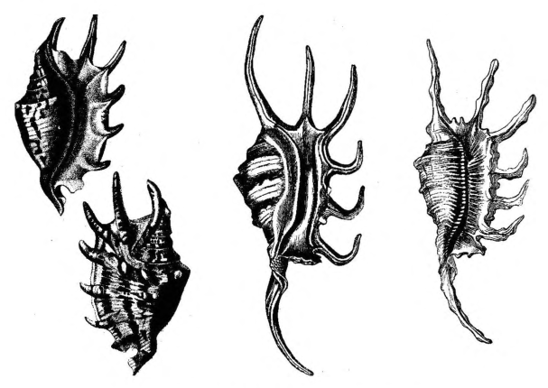

**Figure 4.4:** *Lambis* spp., spider conches

#### 4.2.2. Turbinidae, turbans

The turbans are herbivorous grazers common on intertidal and subtidal reefs, well-known for the operculum or ‘cat’s eye’ which the animal uses to close off the entrance to its shell. Turbans are an important food resource. Wayan has a generic for turbans, *kerekere*, as well as names for several subtaxa, and this pattern appears to be typical of Oceanic languages.

#### 4.2.3. *Turbo petholatus*

For the tapestry turban, Turbopetholatus, there is a well-attested POc reconstruction, *qaliliŋ, which continues a PMP etymon. This term may have served as a generic for the genus.

| **PMP** |  | *qaliliŋ | ‘cat’s eye shell’ (some reflexes indicate initial *w)[^6] |
| --- | --- | --- | --- |
| **POc** |  | *qaliliŋ | ‘*Turbo petholatus*, tapestry turban; possibly generic for several or all *Turbo* spp.’ |
| MM | Tolai | *kaliliŋ* | ‘k.o. shell fish’ |
| SES | Gela | *lili* | ‘*Turbo* spp. (generic)’ |
| SES | Lau | *salili* | ‘*Turbo petholatus*’ |
| SES | To’aba’ita | *thalili* | ‘sp. of turban shell, possibly tapestry turban, *Turbo petholatus*’ |
| SES | ’Are’are | *rariri* | ‘k.o. small shellfish, with cat’s eye’ |
| NCV | Tamambo | *(h)alili* | ‘cat’s eye shell’ |
| NCV | Southeast Ambrym | *lili* | ‘operculum of green snail’ |
| NCV | Namakir | *ʔalil* | ‘cat’s eye shell’ |
| **PPn** |  | *qalili | ‘cat’s eye shell, *Turbo* sp.’ (pollex) |
| Pn | Tongan | *ʔelili* | ‘a shellfish with cat’s eye’ |
| Pn | Niuatoputapu | *ʔelili* | ‘*Turbo* sp.’ |
| Pn | Rennellese | *ʔaŋiŋi* | ‘turban shells, *Turbo petholatus*, used for spoons’ |
| Pn | Samoan | *alili* | ‘a mollusc, *Turbo* sp.’ |
| Pn | Tikopia | *alili* | ‘greensnail; *Turbo* spp. incl. *Turbo marmoratus*, *Turbo argyrostomus*, *Turbo setosus*’ |

#### 4.2.4. Other Turbo taxa

Usually a number of turban shell taxa are named, sometimes by a compound using a reflex of *mata ‘eye’, with reference to the operculum. The second element of PEOc *mata-buku is probably *buku ‘knot, lump, protruberance’.

| **PEOc** |  | *mata-buku | ‘*Turbo* spp.’ |
| --- | --- | --- | --- |
| SES | Lengo | *mata-puku* | ‘Turbinidae’ |
| Fij | Wayan | *mata-buku* | ‘*Turbo* spp., possibly including *Turbo chrysostoma*, *Turbo argyrostomus*, *Turbo necnivosus*’ |

cf. also:

| MM | Maringe | *pʰupuku* | ‘*Trochus incrassatus*’ |
| --- | --- | --- | --- |
| SV | Anejom̃ | *na-pek* | ‘*Turbo marmoratus*’ |

#### 4.2.5. Cymatiidae, tritons

The tritons are a family of many species, which eat echinoderms and molluscs. The large shell of *Charonia tritonis*, Triton’s trumpet, is widely used as a trumpet for ceremonial purposes or to summon people to meetings. There is a widely-reflected POc reconstruction for triton shells, which continues a PMP etymon.

| **PMP** |  | *tabuRiq | ‘conch shell trumpet’ (dbl. *tabuRi) (Blust 1989) |
| --- | --- | --- | --- |
| **POc** |  | *tapuRiq | (1) ‘generic for conch shells, esp. triton’s trumpet, *Charonia tritonis* and allied spp.; possibly extended to some *Cassis* (helmet) shells’; (2) ‘trumpet of *Charonia* shell’ |
| Adm | Mussau | *taue* | ‘triton shell’ |
| NNG | Kove | *taule* | ‘triton’s trumpet, used for sending messages’ |
| NNG | Gedaged | *tauɬ* | ‘triton shell’ |
| NNG | Manam | *tauru* | ‘conch; used as a wind instrument’ |
| NNG | Mangap | *twiiri* | ‘trumpet shell, Triton’ |
| PT | Kilivila | *tauya* | ‘triton shell; trumpet of this’ |
| MM | Nalik | *tafuru* | ‘triton shell’ |
| MM | Sursurunga | *taur* | ‘triton shell, blown to send messages’ |
| MM | Patpatar | *tahur* | ‘triton shell’ |
| MM | Vitu | *tavure* | ‘triton shell’ |
| SES | Gela | *tavuli* | ‘triton shell; helmet shell, *Cassis cornutus*: a trumpet’ |
| SES | Arosi | *ahuri* | ‘conch shell, triton; trumpet of this, blown only on solemn occasions, e.g. at a death’ |
| SES | Arosi | *ahuri (poru)* | ‘k.o. *Cassis* shell’ |
| SES | Sa’a | *ehuri* | ‘conch shell, blown as a summons’ |
| TM | Buma | *teveliko* | ‘triton shell’ (François 2011b) |
| NCV | Mota | *tawe* | ‘conch shell’ |
| NCV | Mwotlap | *na-tʊ* | ‘conch shell’ |
| NCV | Lonwolwol | *taviu* | ‘conch shell (and sound)’ |
| NCV | Nguna | *tavui* | ‘triton shell’ |
| SV | Sye | *n-tovu* | ‘triton shell’ |
| SV | Anejom̃ | *n-tohou* | ‘triton shell’ |
| Mic | Kiribatese | *tau* | ‘triton conch’ |
| Mic | Woleaian | *tawii* | ‘conch shell; trumpet’ |
| Fij | Bauan | *davui* | ‘Triton’s trumpet; used as a trumpet, chiefly on canoes’ |
| Fij | Wayan | *tavui* | ‘Triton’s trumpet and allied spp.; trumpet of this’ |

#### 4.2.6. Neritidae, nerites, and allied families of Neritacea

Typical nerites have globular shells with flattened base. They are vegetarians, living under rocks or in crevices close to the high tide mark. The nerite family contains marine, freshwater and terrestrial species. The wide range and abundance of nerites, and their importance as food, may explain why the generic for this family has come to be used as a generic for a wider range of gastropods in a number of Oceanic languages, including Takia, Roviana, Bauan, Wayan and Samoan.

| **PMP** |  | *sisi[q] | ‘edible snail’ (doublets *sisuq, *susuq) (Blust 1980b) |
| --- | --- | --- | --- |
| **POc** |  | *sisiq | (1) ‘various small, snail-like gastropods of nerite family’; (2) ‘probably generic for a wider class of edible gastropods’ |
| NNG | Takia | *sise(i)* | ‘generic term for all varieties of sea shells’ |
| PT | Molima | *sisi(ʔalo)* | ‘a brown bivalve, small and edible, found in tidal flats’ |
| MM | Nakanai | *e-sisi* | ‘k.o. shellfish’ |
| MM | Teop | *hihi* | ‘Nerita albicilla’ |
| MM | Roviana | *sise* | ‘general name for a number of small shells’ |
| MM | Marovo | *sise* | ‘small marine gastropod’ |
| MM | Marovo | *sise (kavo)* | ‘freshwater gastropod’ |
| SES | To’aba’ita | *sisi-* | ‘first element in several compounds for kinds of shellfish’ |
| SES | ’Are’are | *sisi* | ‘a big sea shell’ |
| SES | ’Are’are | *sisi-* | ‘first element in compounds for kinds of gastropods’ |
| SES | Arosi | *sisi(apiro)* | ‘limpet’ |
| SES | Lau | *sisi(afufu)* | ‘mollusc sp.’ |
| SES | Gela | *hihi(vuhi)* | ‘freshwater snail sp., *Neritina brevispina*’ |
| NCV | Mwotlap | *nɛ-sɛs* | ‘*Nerita plicata*, generic for molluscs’ |
| NCV | Ambae | *hihe* | ‘*Nerita* sp.’ |
| NCV | Southeast Ambrym | *ses* | ‘shellfish of family Neritidae’ |
| NCV | Tamambo | *sise* | ‘shellfish sp.’ |
| NCV | Nguna | *sisa* | ‘snail including nerites’ |
| NCV | Raga | *hiha* | ‘seasnail, winkle’ |
| NCV | South Efate | *ses* | ‘nerite’ |
| NCal | Cèmuhî | *ti* | ‘generic term for gastropods’ |
| NCal | Fwai | *tʰik* | ‘trochus, but used generically for gastropods’ |
| NCal | Nemi | *tʰik* | ‘trochus, but used generically for gastropods’ |
| Fij | Rotuman | *sisi* | ‘edible shell-fish, the periwinkle’ |
| Fij | Bauan | *siði* | (1) ‘*Trochus* spp.’; (2) ‘first element in various compounds naming kinds of gastropods and a few bivalves’ |
| Fij | Wayan | *ðiði* | ‘generic for gastropods’ |
| **PPn** |  | *sisi | ‘a univalve mollusc’ (pollex) |
| Pn | Niuatoputapu | *hihi* | ‘*Nerita* spp.’ |
| Pn | Niuean | *hihi-* | ‘first element in compound names for some gastropods’ |
| Pn | Samoan | *sisi* | ‘name given to small snails in general’ (Milner 1966) ; ‘freshwater molluscs’ (Pratt 1862) |
| Pn | East Futunan | *sisi* | ‘small shellfish spp., Neritidae and Naeticidae’ |
| Pn | Tikopia | *sisi* | ‘a range of marine and land snails incl. *Melampus* spp. and *Nerita* spp.’ |
| Pn | Rennellese | *sisi* | ‘edible Nerita shells’ |

cf. also:

| NNG | Yabem | *usu* | ‘sea snails (general term)’ |
| --- | --- | --- | --- |
| PT | Motu | *dudu* | ‘name of a shellfish’ (*u* for †*i*) |

Some WOc and NCV languages reflect *siseq or *sisaq rather than *sisiq. These departures can be explained in terms of dissimilatory change in which the final, unstressed vowel is lowered. Dissimilation of the final vowel, *sisiq > *sisu* > *susu*, also explains Motu *dudu* for expected *didi.

#### 4.2.7. Cypraeidae (cowries) and Ovulidae (egg and spindle cowries)

Many species of cowries are present. The white or egg cowrie (*Ovula ovum*) is used in some societies as a decoration associated with chiefs and chiefly property. In Fiji, for example, these shells are hung from the ridge-pole of a chief’s house and in the western Solomons they are used as prow ornaments on war canoes. Oceanic languages generally classify cowries and ovulids together under a single generic with subtaxa distinguished by binomials. There is a well-attested POc reconstruction which continues a PMP etymon.

| **PMP** |  | *buliq | ‘cowrie shell’ (Blust 1980b) |
| --- | --- | --- | --- |
| **POc** |  | *buli(q) | ‘generic for cowries’ |
| NNG | Takia | *bul* | ‘k.o. shellfish: *Ovula ovum*, white egg cowrie’ |
| PT | Kilivila | *bune-buna* | ‘cowrie’ |
| PT | Molima | *buli* | ‘cat’s eye (operculum of shell)’ |
| MM | Tabar | *buri-buri* | ‘big cowrie shell’ |
| MM | Maringe | *buli* | ‘cowrie shell’ |
| SES | Gela | *buli* | ‘generic for cowries’ |
| SES | To’aba’ita | *bull* | ‘egg cowrie, *Ovula ovum*’ |
| SES | Lau | *buli* | ‘white cowrie, *Ovula ovum*’ |
| SES | Sa’a | *puli* | ‘cowrie shell, used as sinkers for nets’ |
| NCV | Mwotlap | *(nʊ-wʊ)pʷʊl* | ‘cowrie shell, not edible; *Cypraeidae spp*.’ |
| NCV | Nguna | *pule* | ‘cowries’ |
| Mic | Ponapean | *pʷili* | ‘cowrie shell’ |
| Mic | Puluwatese | *pʷiliy* | ‘cowry shell; to scrape, as breadfruit’ |
| Fij | Bauan | *buli* | ‘cowrie shell’ |
| Fij | Wayan | *buli-buli* | ‘cowrie shell: generic term for Cypraeidae and Ovulidae’ |
| **PPn** |  | *pule | ‘cowrie’ |
| Pn | Samoan | *pule* | ‘cowrie’ |
| Pn | Niuean | *pule* | ‘cowrie, *Cyprea* sp.’ (*pule tea* ‘white cowry, *Ovula ovum*’) |

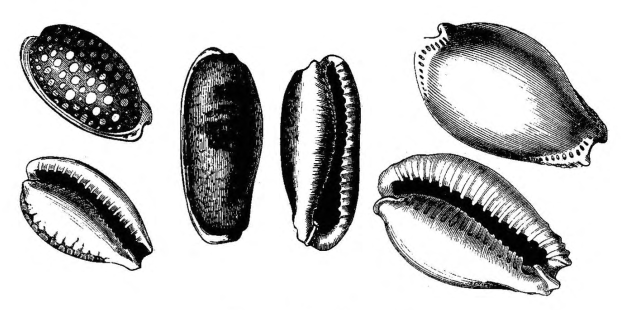

**Figure 4.5:** Cowries

#### 4.2.8. Trochidae, top shells

The Trochidae are a family of shallow water dwellers, represented by many species, with conical shells and flat or convex circular base. Some are a valued food resource. Oceanic peoples traditionally made ornaments, such as arm and wrist bracelets, from trochus shell. Oceanic languages usually have a generic term for the family and several binomials naming subtaxa. There is a good chance that the term *lalai*, which entered Tok Pisin from Tolai, has spread from Tok Pisin into many vernacular languages of Papua New Guinea and the Solomons.

| **PMP** |  | *lalak | ‘trochus shell’ (Blust 2002) |
| --- | --- | --- | --- |
| **POc** |  | *lala(k) | (1) ‘*Trochus* spp., including *Trochus niloticus* and possibly *Trochus stellatus*’; (2) ‘rings or armlets made of this’ |
| NNG | Wogeo | *lala* | ‘pearl shell’ |
| MM | Tolai | *lalai* | ‘*Trochus* spp., armlet made from trochus shells’ |
| MM | Maringe | *glala* | ‘*Trochus niloticus*’ |
| SES | Gela | *lala* | ‘*Trochus niloticus*’ |
| SES | Longgu | *lala* | ‘*Trochus niloticus*’ |
| NCV | Mota | *lala* | ‘top shell; bracelet made of this’ |
| NCV | Raga | *lala* | ‘*Trochus stellatus*: shell armlet, ring’ |
| NCV | Tamambo | *lala* | ‘trochus’ |
| NCV | Uripiv | *na-lel* | ‘trochus shell’ |

cf. also: the following, all possibly borrowed from Tok Pisin *lalai*

| Adm | Mussau | *lailai* | ‘pearlshell’ |
| --- | --- | --- | --- |
| NNG | Kove | *lalai* | ‘pearlshell’ |
| MM | Bali | *lailai* | ‘pearlshell’ |

#### 4.2.9. Conidae, cone shells

The Conidae are all conical in shape, usually with long narrow aperture and smooth outer lip. Species vary greatly in length, ranging from 6 mm to 230 mm. The Conidae are carnivores and inflict a venom with a radular dart on the proboscis. The larger shells are much used for making bracelets and rings. There is a term attributable to PEOc whose SES reflexes generally refer both to the shell itself and to bracelets and other ornaments made of cone or trochus shell.

| **PEOc** |  | *lako | (1) ‘cone or trochus shell’; (2) ‘various ornaments made from this’ |
| --- | --- | --- | --- |
| SES | Gela | *lago* | ‘cone shells made into ornaments’ |
| SES | Arosi | *raʔo* | ‘trochus shell; various ornaments made from this; canoe decorated with inlaid shell pieces’ |
| SES | ’Are’are | *raʔo* | ‘cone shell used as ornament on belt or arm; tied on canoes as protection’ |
| SES | Lau | *lao* | ‘generic for *Conus* spp.; ornaments of Conus, canoe decorated with Conus’ |
| SES | Sa’a | *laʔo* | ‘cone shell, trochus; forehead ornament of this or tridacna; armlets; shell inlaid on sides of canoes’ |
| Mic | Puluwatese | *la-* | ‘possessive classifier for bracelets’ |
| Mic | Puluwatese | *lœlœlœ* | ‘use s.t. as a bracelet’ |
| Mic | Woleaian | *raxa* | ‘bracelet, wrist ornament’ |

PSES *kome evidently referred to a particular kind of armlet, made from *lako shell. A partially or fully reduplicated form, *ko-kome or *komekome, may have been a general name for cone shells in PSES. However, given that *kome referred to a valuable trade good, this term may well have spread by borrowing among languages of the central and eastern Solomons.

| **PSES** |  | *kome | ‘armlets made from cone or trochus shell’ |
| --- | --- | --- | --- |
| **PSES** |  | *ko-kome, *kome-kome | ‘generic for cone shells’ |
| MM | Maringe | *kome-kome* | ‘Conidae family (generic)’ |
| MM | Maringe | *kʰome* | ‘cone shell, *Conus leopardus*, used to make armlets’ |
| SES | Arosi | *kome* | ‘white shell armlet of *raʔo* trochus’ |
| SES | Lau | *kome* | ‘Conus’ |
| SES | Sa’a | *ko-kome* | ‘round white armlet of trochus (*laʔo*)’ |
| SES | To’aba’ita | *kome* | ‘armlet, shell of *Conus* sp.’ |
| SES | Kwaio | *kome* | ‘cone shell arm ring’ |
| SES | Kwaio | *kō-kome* | ‘cone shells (generic)’ |

#### 4.2.10. Muricidae, murexes

_Murex_es have large shells, sculptured with knobs and ridges, spines and spinal cords. They are carnivores which live in the subtidal zone especially on sandy mudflats. Numerous species occur in the tropical Pacific.

| **POc** |  | *buRua | ‘*Murex* sp.’ (Geraghty 1990) |
| --- | --- | --- | --- |
| PT | Bwaidoga | *(hewahewa)bulu* | ‘*Murex ramosus*’ |
| MM | Tolai | *burua, bura-burua* | ‘*Murex palmarosae*’ |
| Fij | Wayan | *bua* | ‘*Murex* spp.’ |

cf. also:

| NNG | Kove | *vuru* | ‘cone shells and ornaments made from these’ |
| --- | --- | --- | --- |
| MM | Nakanai | *e-buru* | ‘cone-shaped shellfish’ |

#### 4.2.11. Gastropod families lacking POc names

For many groups of gastropods present in the tropical Pacific region no reconstructions have been made to POc level, even though names for these groups are present in contemporary languages. For example, POc names are missing for limpets (Patellidae), key-hole limpets (Fissurellidae), ceriths (Cerithidae), cones (Conidae), dog-whelks (Nassaridae), mud-whelks (Potomididae), helmet shells (Cassidae), tun shells (Tonnidae), miters (Mitridae), augers (Terebridae), turrids (Turridae) and drupes (Thaidinae).

There are ten pretty secure POc reconstructions for kinds of bivalves: *japi, *kaRi, *kasi *kuku, *kima, *sapulu(q), *tiRom, *tu(qu)asi, *tu(q)e-tu(q)e and *(w,y)aro.

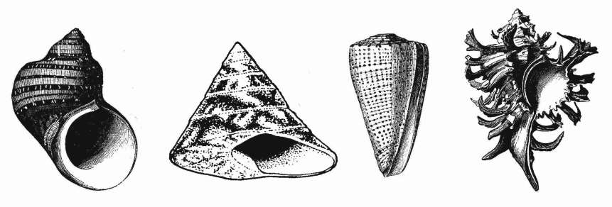

**Figure 4.6:** Left to right Univalve shells: turban, trochus, cone, murex

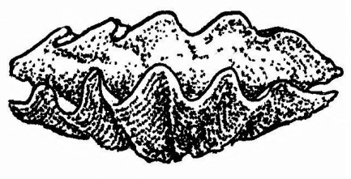

**Figure 4.7:** *Tridacna gigas*, giant clam

Giant clams are a small but economically important group that includes the largest externally shelled molluscs. The largest species (*Tridacna gigas*) grows up to a metre long. Traditionally regarded as a separate family, this group has recently been reclassified as a subfamily Tridacninae of *Cardiidae*. Giant clams are prized food, consumed at ceremonial feasts. In some societies edge-ground adze blades and shell rings were made from the heavy shells. Typically Oceanic languages have a generic referring to all *Tridacna*, with several binomials distinguishing subtaxa. Thus Arosi *ʔima* is the generic and there are eight binomials (including one pair of synonyms) denoting subtaxa. Wayan has *vāsua* as the generic and has three subtaxa: *(vasua) cavucavu*, *Tridacna gigas*, the largest kind, which is easily removed, and is symbolic of women because they marry away from home; *kativatu*, *Tridacna maxima*, is hard to remove and is symbolic of men, who stay with their father’s clan; and *vosavosa*, the fluted clam, *Tridacna squamosa*.

There is a well-attested POc generic for giant clams, *kima, with a PMP antecedent.

| **PMP** |  | *kima | ‘giant clam, *Tridacna* spp.’ (Blust 2002) |
| --- | --- | --- | --- |
| **POc** |  | *kima | ‘giant clam, *Tridacna* spp., include. *Tridacna gigas*’ |
| PT | Molima | *ʔimaʔima* | ‘a shell which is used as a scraper’ |
| PT | Wedau | *kimei* | ‘clam shell’ |
| PT | Tawala | *kima* | ‘clam shell’ |
| MM | Tabar | *kima* | ‘clam’ |
| SES | Gela | *gima* | ‘*Tridacna gigas*’ |
| SES | Sa’a | *ʔime* | ‘giant clam variety’ |
| SES | To’aba’ita | *ʔima* | ‘generic for giant clams’ |
| SES | Longgu | *ʔima* | ‘large clam’ |
| NCV | Mota | *gima* | ‘giant clam variety’ |
| Mic | Kiribatese | *kima* | ‘tridacna’ |

Reflexes of *kima are absent from Central Pacific, where it was evidently replaced by *(b,v)āsua. This was the PCP reflex of a PEOc term for a large but unidentified shellfish species. Reflexes show unexplained variation in the initial consonant.

| **PEOc** |  | *(b,v)asua | ‘large shellfish, perhaps a bivalve’ |
| --- | --- | --- | --- |
| SES | Gela | *(pau)pasua* | ‘*Murex* spp.’ |
| SES | Arosi | *(han) wasua* | ‘oyster’ (initial w- unexpected) |
| NCV | Uripiv | *na-basow* | ‘scallop, *Pallium* sp., and Spondylus rubicundus’ |
| **PCP** |  | *(b,v)āsua | ‘giant clam, *Tridacna* spp.’ |
| Fij | Wayan | *vāsua* | ‘generic for *Tridacna* spp.’ |
| Fij | Bauan | *vāsua* | ‘giant clam, *Tridacna* spp.’ |
| **PPn** |  | *(p,f)āsua | ‘*Tridacna* clam sp.’ |
| Pn | Samoan | *fāisua* | ‘*Tridacna* sp., giant clam’ (-*i-* irregular) |
| Pn | Rennellese | *hāsua* | ‘general term for *Tridacna* spp.’ |
| Pn | Emae | *fāsua* | ‘*Tridacna* sp., giant clam’ |
| Pn | Ifira-Mele | *vasu-vāsua* | ‘k.o. edible bivalve’ |
| **PEPn-Northern Outlier** |  | *pāsua | ‘*Tridacna* sp. or spp.’ |
| Pn | Sikaiana | *pāsua* | ‘clam’ |
| Pn | Tokelauan | *pāua* | ‘poisonous shellfish attached under shelving coral’ |
| Pn | Nukuoro | *pāsua* | ‘*Tridacna maxima*’ |
| Pn | Tahitian | *pāhua* | ‘*Tridacna elongata*’ |
| Pn | Rarotongan | *paʔua* | ‘clam, oyster’ |
| Pn | Marquesan | *pahua* | ‘oyster sp.’ |

cf. also:

| Pn | Tongan | *vāsua* | ‘clam’ (borrowed from Fijian) |
| --- | --- | --- | --- |

The Gela and Arosi comparisons are problematic but they provide evidence, consistent with some Eastern Polynesian witnesses, that PCP *(b,v)asua derived from a pre Central Pacific form that referred to a group of bivalves other than the Tridacninae.

#### 4.3.2. *Asaphis* spp. (Psammobidae) and cockles (*Cardiidae*)

There is a well-supported POc form, *kasi, which referred to to the action of grating or scraping, to scrapers made from the valves of circular bivalves, such as *Asaphis* (Psammobidae) and cockles (*Cardiidae* spp.) and to the shellfish themselves, which are good eating. The vernacular term ‘cockle’ is used loosely in many sources, referring not just to shells of the *Cardiidae* family but also to other small to medium-sized rounded bivalves with radial or concentric striae, including Psammobidae and Tellinidae.

| **POc** |  | *kasi | [v] ‘to scrape; scraper or grater made from robust circular bivalve shell, such as Asaphis and cockles’; [N] ‘shellfish taxon, esp. *Asaphis* spp.’ (cf. vol.1, pp.162, 238-240) |
| --- | --- | --- | --- |
| PT | Tawala | *kahi* | ‘pearl shell’ |
| MM | Nakanai | *kasi* | ‘mussel or clam; mussel shell used as knife’ |
| Fij | Rotuman | *ʔɔsi* | ‘cockle, shell much used for scraping’ |
| **PPn** |  | *kasi | ‘shellfish, *Asaphis* spp.’ (pollex) |
| Pn | Tongan | *kahi* | ‘name of a mussel’ |
| Pn | Niuatoputapu | *kahi* | ‘*Asaphis violascens*’ |
| Pn | Samoan | *ʔasi* | ‘a mussel, *Area* sp.’ |
| Pn | Nukuoro | *kasi* | ‘*Asaphis dichotoma*’ |
| Pn | Tikopia | *kasi* | ‘bivalve mollusc, *Asaphis violascens*, and possibly other related bivalves; shell used as cutting or scraping implement’ |
| Pn | Rarotongan | *kaʔi* | ‘*Asaphis violascens*’ |
| Pn | Māori | *kahi* | ‘*Amphidesma australe* and certain other bivalves’ |

cf. also:

| Mic | Carolinian | *xātil* | ‘very small clams (thumb sized) used in soups’ |
| --- | --- | --- | --- |

The next term, POc *kaRi, may have referred to cockles or may have been a more general term for a wider range of small to medium-sized bivalves.

| **POc** |  | *kaRi | ‘bivalve sp. or spp., possibly cockle, used as a scraper’ (Geraghty 1990; cf. vol.1, p.162) |
| --- | --- | --- | --- |
| NNG | Manam | *ʔoriʔori* | ‘pearl shell, traditionally used to scrape coconuts; coconut grater, scraper’ |
| SES | Gela | *gali* | ‘species of mollusc, *Asaphis* sp. (eaten)’ |
| SES | To’aba’ita | *ʔali* | ‘bivalve sp., used as scraper and spoon’ |
| SES | Sa’a | *ali* | ‘cockle’ |
| NCV | Mota | *ɣar* | (1) ‘cockle’; (2) ‘to scrape’ |
| NCV | Raga | *gari* | ‘cockle shell; used as a scraper’ |
| Fij | Bauan | *kai* | ‘generic name of bivalve shellfish’ |
| Fij | Bauan | *kai-koso* | ‘generic for several bivalves’ |

PPn *pipi appears to have applied to various circular bivalves including *Asaphis* sp. or spp. Its reflexes are of interest because in several cases (Kapingamarangi, Pukapukan, Rennellese and Tikopia) they have become a generic for bivalves.

| **PPn** |  | *pipi | ‘probably general name for small or medium-sized circular bivalves, including cockles, *Asaphis* spp.’ |
| --- | --- | --- | --- |
| Pn | Tongan | *pipi* | ‘shellfish sp.’ |
| Pn | Samoan | *pipi* | (1) ‘kind of cockle, *Asaphis* sp.’; (2) ‘shell scraper for barkcloth’ |
| Pn | Tokelauan | *pipi* | (1) ‘*Asaphis* sp.’; (2) ‘scraper of this’ |
| Pn | Tuvalu | *pipi* | ‘*Asaphis* sp., *Nerita* spp.’ |
| Pn | Rennellese | *pipi* | ‘circular bivalves’ |
| Pn | Kapingamarangi | *pipi* | (1) ‘*Asaphis* sp.’; (2) ‘general term for small clams’ |
| Pn | Tikopia | *pipi* | ‘bivalve of many spp.’ |
| Pn | Pukapukan | *pipi* | ‘general name for clams’ |
| Pn | Māori | *pipi* | ‘*Paphies australis*, *Chione stutchburyi*’ |

#### 4.3.3. Mytilidae, mussels

Mussels occur in dense colonies on rocky shores, attaching themselves to surfaces by byssus threads. They fall into several subfamilies. *Mytilus* spp. predominate in cold waters but in tropical waters they are replaced by species of the subfamilies Modiolinae and Lithophaginae. Commonly Oceanic languages distinguish two or more mussel taxa by name, e.g. Wayan has a generic term *boro*, with two subtaxa: *boro boro*, probably *Modiolus plumescens*, and *drivi* ’small mussels with black shell, possibly *Lithophaga* sp.

Blust (1972:10) relates POc *kuku(r) ‘? mussel sp.’ to PAn *kuDkuD ‘rasp, file’, noting reflexes such as Tagalog *kudkod*, Toba Batak *hurhur* ‘grated’, Ngadju Dayak *kukur* ‘rasp, grater’. It is likely that POc *kuku(r) was polysemous, referring both to food scrapers of various kinds of shells and to mussels, which were used as scrapers.

| **POc** |  | *kuku(r) | ‘mussel sp. or spp., used as food grater or scraper’ (see vol.1, p. 161) |
| --- | --- | --- | --- |
| Adm | Lou | *kuki* | ‘shell used to scrape coconut’ |
| NNG | Takia | *kuk* | ‘shellfish: *Anadara* sp., cockle shell’ |
| NNG | Kove | *kuku* | ‘little black horse mussel’ |
| SES | Gela | *ɣuɣu* | ‘mollusc sp.’ |
| SES | Arosi | *kuku* | ‘a small bivalve, *Area* sp.’ |
| NCV | Lonwolwol | *huhu* | ‘a sharpened shell, for scraping’ |
| Fij | Bauan | *kuku* | ‘generic for mussels, incl. *Modiola* spp.’ |
| **PPn** |  | *kuku | ‘mussel sp. (Mytilidae)’ (pollex) |
| Pn | Tongan | *kuku* | ‘pink-fleshed mussel’ |
| Pn | Niuean | *kuku* | ‘a small black mussel’ |
| Pn | Samoan | *ʔuʔu* | ‘mussel, *Modiola* sp.’ |
| Pn | East Futunan | *kuku* | ‘mussel sp. (Mytilidae)’ |
| Pn | Rarotongan | *kuku* | ‘mussel sp., *Mytilus edulis*’ |
| Pn | Rennellese | *kuku* | ‘*Tellina discus*’ |

#### 4.3.4. Ostreidae, rock oysters

The English folk category ‘oyster’ refers to several families of bivalves, including Ostreidae (typical oysters), Isognomonidae (mangrove oysters), Malleidae (hammer oysters), Pteridae (pearl and wing oysters) and Spondylidae (thorny oysters), the latter being more closely related to scallops than to the other ‘oyster’ families. Wayan Fijian has a generic term, *ðiva*, with a similarly broad range of reference.

POc *tiRom continues a PAn term for oyster. The range of the POc term probably included both typical oysters (Ostreidae), which attach themselves by cementing one valve to rocks or wood, and tree oysters (Isognominidae), found mainly among mangrove roots or under rocks in the intertidal zone. Only a few species of Isognomonidae occur in the Pacific Islands.

| **PMP** |  | *tiRem | ‘oyster (Ostreidae)’ (Blust 2002; Dempwolff 1938) |
| --- | --- | --- | --- |
| **POc** |  | *tiRom | ‘oyster (Ostreidae, Isognomonidae)’ |
| Adm | Lenkau | *tireŋ* | ‘k.o. shell’ |
| NNG | Kove | *tiro* | ‘*Crassostrea commercialis*, oyster found on stones and mangroves’ |
| NNG | Kove | *tiromu* | ‘oyster (edible)’ (borrowed from Bali?) |
| NNG | Mangap | *tir* | ‘freshwater shellfish type’ |
| PT | Motu | *siro* | ‘oyster’ |
| MM | Nakanai | *tiro* | ‘mangrove oyster’ |
| SES | Gela | *tilo* | ‘k.o. bivalve, in mangroves and borer in ships’ |
| SES | ’Are’are | *iro* | ‘k.o. oyster living on roots of mangroves’ |
| SES | Arosi | *iro* | ‘small gastropod’ |
| SES | Kwaio | *ilo* | ‘oyster’ |
| NCal | Pije | *diam* | ‘oyster’ |
| NCal | Nemi | *jiem* | ‘oyster’ |
| Fij | Bauan | *dio* | ‘rock oyster’ |
| Fij | Wayan | *tio* | ‘generic for rock oysters (Ostreidae)’ |
| **PPn** |  | *tio | ‘oyster sp.’ (POLLEX) |
| Pn | Tongan | *sio* | ‘rock oyster’ |
| Pn | East Futunan | *tio* | ‘rock oyster’ |
| Pn | Samoan | *tio* | ‘mollusc, *Vermetus* sp.; iridescent fish lure made from its shell’ |
| Pn | Tokelauan | *tio* | ‘gastropod, *Vermetus* sp. (Vermitidae)’ |

#### 4.3.5. Pteridae, pearl and wing oysters, and Malleidae, hammer oysters

The family Pteridae includes pearl and wing oysters, which live on rocky ocean floors. They have moderate to large shells with one valve more inflated, with pearly interior. The Malleidae, hammer oysters, have ears drawn out into elongate wings. The common hammer oyster, *Malleus malleus*, anchors to the bottom in shallow reef waters.

The gold-lip pearl shell, *Pinctada maxima*, and the black-lip pearl, *Pinctada margaritifera*, were traditionally important as a trade item and source of ornaments, especially the breastplate crescent made from the lip of this shell and worn by men. Although they are widely distributed species Swadling (1994) reports that the environmental conditions for dense concentrations of gold- and black-lip pearl shells occur only in a few parts of Papua New Guinea (Manus Province, Ramoaaina Islands, Arawe Islands, Brooker and Moturina in the Calvados chain, eastern Milne Bay Province, and the Torres Strait Islands). Pearl oysters are absent from the more southerly subtropical parts of Polynesia, and in some other parts of Polynesia, including Tonga and Samoa, occur in locations that were not easily accessible to divers. The importance of pearl shell ornaments as trade valuables no doubt led to borrowing of the names for these in some regions. However, the fact that reflexes of *japi, showing regular sound shifts, are found from New Guinea to Polynesia is strong evidence of the POc antiquity of this term.

| **POc** |  | *japi | (1) ‘bivalve taxon, probably *Pinctada maxima*, gold-lipped pearl shell’; (2) ‘ornament made from this’ (see vol. 1, p. 104) |
| --- | --- | --- | --- |
| NNG | Manam | *javi* | ‘pearl shell spoon’ |
| MM | Roviana | *davi* | ‘pearl shell’ |
| MM | Marovo | *davi* | ‘goldlip pearl, *Pinctada maxima*’ |
| SES | Bugotu | *davi* | ‘gold-lip pearl shell’ |
| SES | Gela | *davi* | ‘gold-lip pearl; crescent ornament made from this’ |
| SES | ’Are’are | *tahi* | ‘pearl shell; ornament made of same worn by chiefs’ |
| SES | Arosi | *dahi* | ‘gold-lipped pearl shell’ |
| SES | Sa’a | *dahi* | ‘gold-lipped pearl; crescent breast ornament worn by men, cut from this shell’ |
| **PCP** |  | *jiva | ‘pearl oyster, including *Pinctada* spp.’ (metathesis) |
| Fij | Bauan | *ðiva* | (1) ‘pearl and wing oysters (*Pinctada* spp. and *Avicula* spp.), hammer oyster (*Malleus* sp.)’; (2) ‘breastplate of pearl shell in frame of whale’s tooth ivory’ |
| Fij | Bauan | *ðiva-ðiva* | ‘small oyster, *Pinctada* matensis’ |
| Fij | Wayan | *ðiva* | (1) ‘pearl and winged oysters, including blacklip pearl, *Pinctada margaritifera*, and giant wing oyster’; (2) ‘generic for all kinds of oysters’ |
| Pn | Tongan | *sifa* | ‘pearl shell breastplate’ |
| Pn | Niuean | *tifa* | ‘mother of pearl shell and ornament’ |
| Pn | Tikopia | *tifa* | ‘large pearl shell, formerly worn by men of rank as a breast ornament. Types include *Pinctada margaritifera*, *Pinctada maxima*, *Isognomon isognomum*, *I. perna* and *Pinna* sp.’ |
| Pn | Rarotongan | *tiʔa* | ‘pearl shell breastplate’ |

cf. also:

| PT | Hula | *ravivi* | ‘clamshell’ |
| --- | --- | --- | --- |

The next two sets probably belong to the same etymon, *w/y* crossover occurs in certain other forms. The Gela reflex is compatible with either set because word-initial *w is lost in Gela.

| **POc** |  | *(y)aro(q) | ‘black-lipped pearl, *Pinctada maxima*’ (possibly generic for *Pinctada* spp.) |
| --- | --- | --- | --- |
| NNG | Bing | *yar-yar* | ‘blacklip pearl oyster shell, *Pinctada maxima*’ |
| NNG | Gedaged | *jaɬ* | ‘goldlip pearl’ |
| NNG | Mangap | *yar-yar* | ‘saltwater shellfish, very colourful’ |
| PT | Motu | *laro* | ‘small pearl shellfish; shell used for cutting and paring’ (*l-* a sporadic accretion in Motu) |
| MM | Roviana | *aro(moi)* | ‘k.o. large oyster’ |
| MM | Nduke | *aro(moi)* | ‘large oyster found on reef, *Pycnodonata hyotis* (= *Ostrea hyotis*)’ |
| SES | Lengo | *aro* | ‘oyster’ |

| **PEOc** |  | *waro(q) | ‘probably black-lipped pearl, *Pinctada maxima*, possibly generic for *Pinctada* spp.’ |
| --- | --- | --- | --- |
| SES | Gela | *aro* | ‘black-lip pearl, *Pinctada margaritifera*’ |
| SES | Arosi | *waro* | ‘black-lip pearl’ (waro-anakaoea, scallop, *Pecten* sp.’) |
| SES | To’aba’ita | *kʷaro* | ‘pearl oyster, *Pinctada margaritifera*’ |
| SES | To’aba’ita | *kʷaro(mēmena)* | ‘pearl oyster sp., dark yellow tinge, probably *Pinctada maxima*, black-lip pearl’ |
| Fij | Wayan | *waro* | ‘pen shell, *Pinna* sp.’ |

#### 4.3.6. Pinnidae, pen shells

The Pinnidae or pen shells have large fragile shells. They live buried in soft sand anchored by a silk byssus. The following reconstruction is tentatively associated with the genus *Pinna* because of the Gela and Fijian reflexes. In Cristobal-Malaita languages the reflex refers to black mussels, from which bonito hooks are made.

| **POc** |  | *sapulu(q) | ‘bivalve mollusc, possibly *Pinna* sp.’ |
| --- | --- | --- | --- |
| NNG | Kove | *ravulu* | ‘k.o. razor shell’ |
| SES | Gela | *havulu* | ‘k.o. mollusc, *Pinna* sp.’ |
| SES | Bugotu | *havulu* | ‘scallop’ (Ivens: gloss dubious) |
| SES | ’Are’are | *tahuri* | ‘a black mussel’ |
| SES | Arosi | *tahuru* | ‘black mussel sp., used to make bonito hooks’ |
| SES | Sa’a | *tehulu* | ‘black mussel, used to make bonito hooks’ |
| SES | To’aba’ita | *fulu* | ‘shellfish with black shell’ |
| Fij | Bauan | *savulu* | ‘a shellfish, *Pinna squamosa*’ |

#### 4.3.7. Lucinidae and allied families

Lucinoidea (Lucinidae and three other families) are often the dominant bivalves in shallow sea grass bed habitats, esp. species of *Codakia*, *Ctena*, *Lucina*, *Lucinisca*, *Loripes* and *Anodonta*, and are an important food source. The Lucinidae have certain unusual anatomical features including a foot, used for burrowing, that can be extended 4 to 6 times the length of the animal. There is no secure POc reconstruction for this family but the following is a candidate.

| **POc** |  | *tu(q)e, *tu(q)e-tu(q)e | ‘k.o. bivalve, possibly Lucinidae and allied families’ |
| --- | --- | --- | --- |
| NNG | Kove | *tue* | ‘*Geloina coaxans*, a cockle-like clam of mangrove forest (Corbiculidae)’ |
| NNG | Kove | *tue-tue* | ‘*Codakia tigerina* (Lucinidae), *Quidnipagus palatum* (Tellinidae)’ |
| SES | Gela | *tue* | ‘*Batissa* sp., possibly *Batissa unioniformis*, a commonly harvested small bivalve used as a scraper’ |
| SES | Gela | *tue-lovo* | ‘*Pecten* sp.’ |
| SES | Gela | *tue-koraga* | ‘freshwater bivalve’ |
| SES | Gela | *tue-kunukunu* | ‘very long *Batissa* sp.’ |
| SES | Gela | *tue-tue* | (1) ‘*Tellina* spp.’; (1) ‘young *tue*’ |
| SES | Ghari | *tue* | ‘black freshwater oyster’ |
| SES | Ghari | *tue-tue* | ‘small white edible shellfish’ |
| SES | Lengo | *tue* | ‘mangrove shell’ |
| SES | Lengo | *tu-tue* | ‘sea shell’ |
| SES | Tolo | *tue-tue* | ‘small freshwater shellfish’ |
| Pn | Tongan | *tuʔe* | ‘k.o. shellfish with long sharp projections’ |
| Pn | Māori | *tua-tua* | ‘bivalve, Amphidesma subtriangulata’ (syn. of *kahi-tua*, *kai-tua*) |

#### 4.3.8. Reconstructions for bivalves of uncertain family

Some etyma have reflexes that are so semantically diverse or so vaguely glossed in the sources that the reconstructed name cannot be associated with a particular family. For POc *sisira ‘a barnacle or k.o. small mollusc’ see §3.6. The following reconstruction is very tentative, because the putative cognates are few and because the semantic agreement is weak.

| **POc** |  | *tape | ‘k.o. bivalve’ |
| --- | --- | --- | --- |
| NNG | Bilibil | *tave* | ‘giant clam, *Tridacna gigas*’ |
| MM | Teop | *dave* | ‘*Polinices tumidua* (in white sand)’ |
| Fij | Wayan | *tavē* | (1) ‘tellins, sanguins’; (2) ‘generic for a large class of bivalves, excluding oysters and giant clams’ |

The following term may have applied to a kind of pearl shell, with a shift of referent in Bugotu and Maringe arising from the use of pieces of nautilus shell for inlaying in woodwork.

| **PWOc** |  | *bio | ‘k.o. mollusc or pearl shell’ |
| --- | --- | --- | --- |
| NNG | Yabem | *bi* | ‘pearl shell’ |
| NNG | Gitua | *bio-bio* | ‘pearl shell’ |
| NNG | Tami | *biu* | ‘pearl shell’ |
| MM | Nakanai | *beo* | ‘pearl shell’ |
| MM | Tabar | *bio* | ‘k.o. shellfish, Strombidae’ |
| MM | Bola | *bio* | ‘pearl shell’ |
| MM | Maringe | *bio* | ‘nautilus shell, used for inlaying in woodwork’ |
| SES | Bugotu | *bio* | ‘nautilus’ (possibly borrowed from Maringe) |

The following cognate set appears to be restricted to Meso-Melanesian.

| **Proto Meso-Melanesian** |  | *game | ‘k.o. mollusc’ |
| --- | --- | --- | --- |
| MM | Vitu | *game* | ‘k.o. shellfish: *Trochus niloticus*’ |
| MM | Tabar | *gam* | ‘a shellfish’ (possibly from Tok Pisin *gam* ‘baler shell, large cowry shells’) |
| MM | Tangga | *gem* | ‘a bivalve, possibly a small Toigans’ |

cf. also:

| Adm | Mussau | *kame-kame* | ‘bait’ |
| --- | --- | --- | --- |
| NNG | Manam | *gam* | ‘squid’ |

The following term may have referred both to a bivalve shellfish and to spoons or graters made from its shell. Only a single WOc reflex has been noted. The Niuatoputapu reflex points to PPn *tuquahi, with glottal stop, whereas the Tongan reflex points to *tuahi. Those Polynesian forms that refer only to coconut grater may have spread by borrowing.

| **POc** |  | *tu(qu)asi | ‘bivalve taxon, probably ark or cockle shell; possibly also grater or spoon made from this’ |
| --- | --- | --- | --- |
| NNG | Mangap | *tuai* | ‘shellfish type, shell used for scraping root vegetables’ |
| **PCP** |  | *tu(qu)aði | ‘bivalve taxon, probably ark or cockle shell; possibly also grater or spoon made; from this’ |
| Fij | Bauan | *tuasa* | ‘a bivalve, probably *Area* sp.’ (final *-a* irregular) |
| Fij | Wayan | *tuaði* | ‘ark shell, *Anadara* sp. (Arcidae)’ |
| Pn | Tongan | *tuahi* | ‘k.o. shellfish’ |
| Pn | Niuatoputapu | *tuʔuasi* | ‘a cockle, *Laevicardium biradiata* (*Cardiidae*)’ |
| Pn | Samoan | *tuai* | ‘coconut grater’ |
| Pn | Rennellese | *tuai* | ‘spoon or grater, formerly made of shell’ (for †*tuʔuai*) |
| Pn | Rarotongan | *tuai* | ‘coconut grater’ |

#### 4.3.9. Bivalve families lacking definite POc reconstructions

There are several prominent families of bivalves for which no definite POc names can be reconstructed. These include scallops (Pectinidae), thorny oysters (Spondylidae), jewelboxes (Chamidae), tellins (Tellinidae), sanguins (Garidae), wedge shells (Donacidae), venus shells (Veneridae), and olives (Olividae).

#### 4.3.10. Generic term for bivalves

Some contemporary languages have a generic covering all or most bivalves. This is often a polysemous term, which also refers to an important specific taxon. For example, the Bauan generic *kai* is also the term for cockles, Wayan *tavē* is also the term for tellins and sanguins. In several Polynesian languages reflexes of PPn *pipi, probably originally referring chiefly to cockles, has become a generic for a wide range of bivalves (§4.3.2).

### 4.4. Polyplacophora: chitons

Chitons are flattened, slug-like molluscs, most species covered with eight shingle-like plates. They feed on algae. Chitons are usually represented in Oceanic languages by a uninomial generic (e.g. Gedaged *dabag*) and some languages also have several binomials naming specific kinds. There is a well-supported PEOc reconstruction but there are no certain cognates in WOc.

| **PEOc** |  | *tadruku | ‘generic for chitons’ |
| --- | --- | --- | --- |
| SES | Gela | *tadugu* | ‘generic for chitons’ (Foale) |
| Fij | Bauan | *tadruku* | ‘chiton’ |
| Fij | Wayan | *tadruku* | ‘chiton’ |

cf. also:

| MM | Marovo | *tatadu* | ‘generic for chitons’ |
| --- | --- | --- | --- |

In PPn *mama replaced *tadruku as the generic for chitons. PPn *mama is probably cognate with Southeast Solomonic *mama, referring to a kind of anemone or jellyfish (see §6.3).

| **PPn** |  | *mama | ‘chiton’ |
| --- | --- | --- | --- |
| Pn | Tongan | *mama* | ‘seaslug’ |
| Pn | Niuean | *mama* | ‘various slug-like molluscs on reef, probably chiton family’ |
| Pn | Tikopia | *mama* | ‘chiton’ |
| Pn | Marquesan | *mama* | ‘*Chiton magnificus*’ |

### 4.5. A term for shellfish in general

Did POc speakers have a name for shellfish (shelled molluscs) in general? As noted in section 1, POc had a broad collective term, *pinaŋoda, denoting ‘marine invertebrates, sea animals other than fish gathered on the reef’. In a few languages the reflex has become a general term for bivalves and gastropods, sometimes also including sea urchins, e.g. Samoan *fiŋota* ‘generic for shelled molluscs and other invertebrates’, Tokelauan *fiŋota* ‘bivalves, gastropods and sea urchins’.

A term specifically denoting all and only shellfish is present in some Oceanic languages. For example, Foale (1998) reports that Gela (SES) *vaŋuda* is normally used as generic for molluscs but can be extended to include crustaceans and echinoderms. Lau (SES) has a noncognate form with similar function: *karoŋo* (1) ‘shelled mollusc, marine or land’; (2) ‘any invertebrate collected on reef at low tide: shellfish, crabs, squids’, as does Niuean *fua* ‘shellfish and echinoderms’. Motu (PT) has *bisisi* ‘general name for all shellfish’ and Takia (NNG) has *sisei* ‘generic for all varieties of shells’. Akimichi and Sakiyama (1991) report that Penchal (Adm) *mʷel* has two senses: (1) ‘shellfish’; (2)‘shellfish, sea urchins and sea cucumbers’ and that in nearby Lenkau the cognate term *mʷe* also has two senses: (1) ‘shellfish’ and (2) ‘shellfish, cephalopods and sea urchins and sea cucumbers’. We can conclude that POc may well have had a general term for shellfish. However, in the absence of a widespread cognate set no reconstruction can be made.

### 4.6. Cephalopoda: octopus, squid, nautilus

The cephalopods include (1) the octopus and argonaut group, with eight tentacles; (2) the squid and spirula group, with ten, and (3) the chambered nautilus, which inhabits the deep sea and is rarely encountered alive. Groups (1) and (2) are valued food sources.

#### 4.6.1. Octopus

Several species of octopus occur in the Pacific, two common ones being *Octopus cyanea*, the day octopus or common reef octopus, and the smaller *Octopus ornatus*, the night octopus. Some Oceanic languages name several different taxa by size, shape and habits. There is a widely-reflected generic going back to PAn.

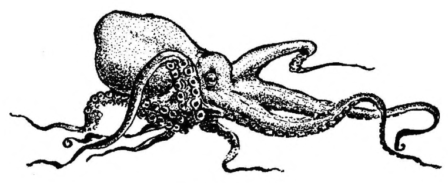

**Figure 4.8:** Octopus

| **PAn** |  | *kuRita | ‘octopus’ (Blust 2002) |
| --- | --- | --- | --- |
| **POc** |  | *kuRita | ‘generic for octopus’ |
| Adm | Titan | *kwit* |  |
| Adm | Mussau | *uita* |  |
| NNG | Gedaged | *uɬit* |  |
| PT | Kilivila | *kuita* |  |
| PT | Motu | *urita* |  |
| MM | Tabar | *urita* |  |
| MM | Sursurunga | *kurit* |  |
| MM | Tolai | *urita* |  |
| MM | Teop | *orita* |  |
| SES | Tolo | *hulita* |  |
| SES | Arosi | *ʔuria* | ‘a small octopus, squid’ |
| NCV | Southeast Ambrym | *uit* | ‘octopus, squid’ |
| NCV | Raga | *guita* | ‘octopus; generic for cephalopods’ |
| NCal | Jawe | *ciia* | ‘octopus’ |
| Mic | Woleaian | *xiusa* |  |
| Fij | Bauan | *kuita* | ‘octopus; generic for cephalophods’ |

#### 4.6.2. Squid and cuttlefish

Squids have 10 arms and a thin, plastic-like internal shell, which in the cuttlefish (*Sepia* spp.) takes the form of a flat rigid bone. Several squid and cuttlefish species occur in Pacific shallow waters, ranging in size from just a few cm to quite large.

POc had at least two terms for squid/cuttlefish taxa: *nusa (with doublet *nus) and *mʷanagi (with doublet *mʷamʷagi).

*nusa and *nus seem to have referred to small squid and small cuttlefish. Blust (1986) reconstructs PMP *nus ‘squid, cuttlefish’, based on forms such as Malay *nus* ‘generic for cephalopods’ and Roti *nus* ‘octopus, squid’, with a doublet *kanuqus. *nusa is reflected by the following:

| **POc** |  | *nusa | ‘small reef squid (*Loligo* spp.) and smaller cuttlefish (*Sepia* spp.)’ |
| --- | --- | --- | --- |
| Adm | Mussau | *nusa* | ‘small squid’ |
| NNG | Bariai | *gusa* | ‘squid’ |
| NNG | Gedaged | *nui* | ‘squid’ |
| NNG | Manam | *nuri* | ‘squid’ |
| PT | Motu | *nuse* | ‘small octopus’ (*-s-* irregular) |
| MM | Nakanai | *luso* | ‘cuttlefish’ |
| MM | Bulu | *guta* | ‘squid’ |
| MM | Maringe | *nuho* | ‘cuttlefish’ |
| SES | Gela | *nuho* | ‘generic for reef squids, Sepioteuthis spp.’ |
| SES | To’aba’ita | *nuta* | ‘cuttlefish sp., relatively small’ |
| SES | Arosi | *nuto, nito* | ‘octopus, squid, smaller than monagi’ |
| SES | Lau | *nuto* | ‘squid’ |
| SV | Anejom̃ | *niθ* | ‘generic for squids’ |
| NCal | Fwai | *nit* | ‘squid’ |
| Mic | Puluwatese | *ŋiit* | ‘cuttlefish’ (*ŋ* for *n irregular) |

cf. also:

| MM | Tolai | *(mara)nua* | ‘octopus sp.’ |
| --- | --- | --- | --- |

POc *nus has reflexes in Admiralties, North New Guinea and Central Pacific.

| **POc** |  | *nus | ‘squid’ |
| --- | --- | --- | --- |
| Adm | Titan | *ñu* | ‘squid’ |
| NNG | Mangap | *nus* | ‘smaller squid type’ |
| Fij | Rotuman | *nu* | ‘squid’ |
| Fij | Bauan | *(kuita) nū* | ‘squid’ |
| Fij | Wayan | *(sulua) nū* | ‘squid’ (sulua ‘octopus’) |
| **PPn** |  | *ŋū | ‘squid’ (POLLEX; *ŋ* for †*w) |
| Pn | Tongan | *ŋū(feke)* | ‘squid, cuttlefish’ (*feke* ‘octopus’) |
| Pn | Nukuoro | *ŋū* | ‘squid’ |
| Pn | Māori | *ŋū* | ‘squid, *Sepia apama*’ |

*mʷanagi (dbl. *mʷamʷagi) possibly referred to larger cuttlefish. This term has reflexes in WOc and in SES.

| **POc** |  | *mʷanagi, *mʷamʷagi | ‘larger cuttlefish, *Sepia* sp. or spp.’ |
| --- | --- | --- | --- |
| Adm | Lenkau | *moman* | ‘cuttlefish’ |
| Adm | Penchal | *mʷamʷak* | ‘large red squid’ |
| Adm | Titan | *mʷuamʷak* | ‘cuttlefish’ |
| NNG | Lamogai-Rauto | *wonek* | ‘squid’ |
| NNG | Akolet | *e-vuñek* | ‘squid’ |
| PT | Kilivila | *mʷanagia* | ‘cuttlefish shell’ |
| PT | Motu | *managi* | ‘large octopus with shell’ |
| MM | Tolai | *managa* | ‘squid’ (*i > *a* by assmilation) |
| MM | Tolai | *munaga* | ‘cuttlefish’ |
| SES | Gela | *managi* | ‘*Sepia* spp., cuttlefish’ |
| SES | ’Are’are | *manaki* | ‘cuttlefish’ |
| SES | To’aba’ita | *wāwaki* | ‘spp. of large cuttlefish’ |
| SES | Arosi | *monagi* | ‘cuttlefish, larger than *nuto*’ |
| NCV | Vera’a | *mʷanak* | ‘cuttlefish, *Sepia* sp.’ |

cf. also:

| NNG | Kove | *mokave* | ‘octopus’ |
| --- | --- | --- | --- |
| NNG | Apalik | *oyuk* | ‘squid’ |

### 4.7. Parts of molluscs

Oceanic languages usually have names for various parts of molluscs including beak, tentacles, suckers of octopus, mantle, foot, proboscis, gonads, innards of shellfish, shell, valve and hinge of bivalves, etc. Only a few part names are reconstructable to the level of POc.

| **PEOc** |  | *buRu | ‘octopus ink, sepia’ (Geraghty 1990) |
| --- | --- | --- | --- |
| SES | Arosi | *buru* | ‘cuttlefish ink’ |
| SES | Sa’a | *bulu* | ‘octopus ink’ |
| Fij | Bauan | *bū(loa)* | ‘octopus ink’ (*loa* ‘black’) |
| Fij | Wayan | *bū(lō)* | ‘octopus ink; ink sac of octopus; poisonous fluid ejected by certain fish’ (*lō* ‘black’) |

| **PMP** |  | *gaway | ‘octopus tentacles’ (Zorc 1994) |
| --- | --- | --- | --- |
| **POc** |  | *kawe | ‘tentacle of a cephalopod’ |
| PT | Motu | *gave* | ‘tentacles of octopus’ |
| SES | Ghari | *gae* | ‘tentacles’ (loss of *v irregular) |
| SES | Sa’a | *ka-kave(na)* | ‘tentacle’ |
| SV | Anejom̃ | *n-ɣeve* | ‘tentacles of a cephalopod’ |
| Fij | Bauan | *kawe* | ‘leg of a crab’ |
| **PPn** |  | *kawe | ‘tentacle of a cephalopod’ (pollex) |
| Pn | Tongan | *kave* | ‘tentacle of cuttlefish’ |
| Pn | East Futunan | *kave(ʔi)* | ‘tentacle’ |
| Pn | Samoan | *ʔave* | ‘tentacle of an octopus’ |
| Pn | Hawaiian | *ʔawe* | ‘tentacle of squid, etc.’ |

| **POc** |  | *mata | ‘the operculum or trapdoor of certain gastropod spp.’ (cf. POc *mata ‘eye, opening, most important part or focal point of a thing’) |
| --- | --- | --- | --- |
| NNG | Gedaged | *mala(n)* | ‘operculum’ |
| MM | Tolai | *mata* | ‘operculum’ |
| MM | Poe | *(mangasi) mata(na)* | ‘operculum of turban shell’ |
| SES | Lau | *mā* | ‘operculum of a univalve’ |
| NCV | Port Sandwich | *mara(n)* | ‘operculum’ |
| Fij | Wayan | *mata* | ‘operculum’ |

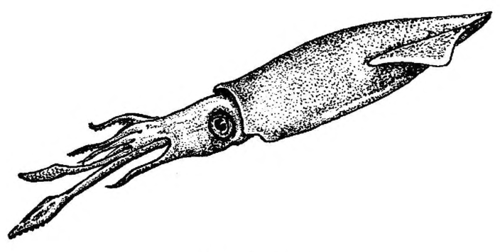

**Figure 4.9:** Squid

### 4.8. Artefacts made from shell

As indicated in §4.1, POc speakers made a variety of artefacts from shell. Reconstructed terms include a number which refer both to the shell and animal and to the artefact made from the shell: *japi ‘crescent breast ornament made from pearl shell, probably worn by high status men’ (§4.3.5), *lala(k) ‘rings or armlets of trochus shell’ (§4.2.8), *tapuRiq ‘trumpet, of triton shell’ (§4.2.5), *buli(q) ‘cowry shell sinkers’ (§4.2.7), *kaRi, *kasi, and *kuku(r) ‘cutting and scraping instruments of bivalve shells’ (§4.3.2, §4.3.5). A few terms for artefacts sometimes or usually made from shell can be reconstructed, e.g. *kiRam ‘adze or axe (generic but applied to edge-ground axes made of tridacna shell), *kawil ‘fish-hook’, and *sabi-sabi ’shell disk used as ear-ring (in Massim made of *Chama pacifica*) (see vol.1,104).

## 5. Echinodermata: sea urchins, sea cucumbers, starfish, etc.

The echinoderms include sea urchins (sea-eggs), sea cucumbers, starfish, brittle stars, feather stars and sand dollars. All possess tube feet and have a body pattern structured in fives. However, the various groups are very diverse in form.

### 5.1. Echinoidea: sea urchins

Sea urchins are represented in Oceania by numerous genera and species. These include long- spined echinoderms (esp. Echinothrix and Diadema spp.), short-spined rock-boring urchins (*Echinometra* spp.) and slate pencil urchins, Heterocentrus mammilatus. Some sea urchins are eaten. It is seems that few Oceanic languages have a folk generic covering all sea urchins. In Wayan echinoderms are recognised as a covert taxon, sometimes referred to by a phrase meaning ‘spiky animals of the reef’.

#### 5.1.1. *Echinometra* spp., rock-boring urchins

There is a POc reconstruction for short-spined rock-boring urchins, *Echinometra* spp., and possibly also *Tripneustes* spp.

| **POc** |  | *saRawaki | ‘k.o. sea urchin, probably *Echinometra* sp. or spp.’ |
| --- | --- | --- | --- |
| NNG | Takia | *sarwag* | ‘sea urchin’ |
| NNG | Mangap | *sarwok* | ‘sea urchin type’ |
| SES | Arosi | *tawaʔi* | ‘k.o. echinus’ |
| Fij | Bauan | *ðāwaki* | ‘k.o. sea urchin with short spikes’ |
| Fij | Wayan | *ðāwaki* | ‘k.o. sea urchin with brittle shell and with short spines, possibly *Tripneustes* sp.’ |
| **PPn** |  | *sāwaki | ‘sea urchin with short spines’ (pollex) |
| Pn | Samoan | *sāvaʔi* | ‘k.o. sea urchin’ |
| Pn | Rennellese | *sābaki* | ‘sea urchin, *Echinometra* sp.’ |
| Pn | Hawaiian | *hawaʔe* | ‘*Tripneustes gratilla*, round black short-spined urchin’ |

cf. also:

| PT | Molima | *salawaʔeʔe* | ‘a purple crab’ |
| --- | --- | --- | --- |

#### 5.1.2. Long-spined sea urchins

The following POc term probably referred to certain long-spined urchins, including *Diadema* spp., and possibly *Astropyga* and *Echinothrix* spp.

| **POc** |  | *sala(n,ŋ) | ‘k.o. sea urchin with long black spines, probably *Diadema* sp. or spp.’ |
| --- | --- | --- | --- |
| Adm | Mussau | *raraŋ(a)* | ‘sea urchin’ |
| NNG | Manam | *sala* | ‘*Diadema setosum*, black long spined sea urchin’ |
| NNG | Kove | *rarala* | ‘sea urchin with long black spines’ |
| PT | Motu | *dala* | ‘sea urchin’ |
| PT | Kilivila | *sanana* | ‘sea urchin’ |
| MM | Halia | *salana* | ‘spiny sea shell’ |
| SES | Gela | *hala* | ‘an echinus, sea egg’ |
| NCV | Paamese | *sal (eimas)* | ‘*Diadema* sp., sea urchin with long black spines’ |

cf. also:

| NNG | Mangap | *sailen* | ‘sea urchin’ |
| --- | --- | --- | --- |

A second term, *gina, is attributable to PEOc, having reflexes in S.E. Solomonic, North-Central Vanuatu and Central Pacific.

| **PEOc** |  | *gina | ‘k.o. sea urchin with long spines’ |
| --- | --- | --- | --- |
| SES | Ghari | *gine* | ‘k.o. sea urchin with sharp spines’ |
| NCV | Raga | *gine(hi)* | ‘sea urchin sp.’ |
| NCV | Namakir | *gin* | ‘sea urchin sp.’ |
| NCV | Nguna | *gida* | ‘sea urchin sp.’ (*-d-* for †*-n- irregular) |
| Fij | Bauan | *gina* | ‘k.o. sea urchin, *Echinus* sp.’ |
| Fij | Wayan | *gina* | ‘k.o. sea urchin with long yellow spines, probably *Echinometrix* spp.’ |
| **PPn** |  | *kina | ‘sea urchin’ (pollex) |
| Pn | Niuean | *kina* | ‘sea urchin’ |
| Pn | Samoan | *ʔina* | ‘k.o. sea urchin’ |
| Pn | Māori | *kina* | ‘k.o. sea urchin with long sharp spines, *Evechinus chlorolicus*’ |
| Pn | Hawaiian | *ina* | ‘small rock-boring urchins, *Echinometra* spp.’ |

The term *wana, for a long-spined urchin, is tentatively attributable to PCP.

| **PCP** |  | *wana | ‘sea urchin, probably *Diadema* sp. and/or *Echinothrix* spp.’ |
| --- | --- | --- | --- |
| Fij | Rotuman | *vᴂnᴂ* | ‘k.o. sea urchin’ (possibly a Polynesian loan) |
| **PPn** |  | *wana | ‘sea urchin sp.’ (pollex) |
| Pn | Niuean | *vana* | ‘sea urchin, *Echinothrix* sp.’ |
| Pn | East Futunan | *vana* | ‘sea urchin with long black spines’ |
| Pn | Tikopia | *vana* | ‘*Diadema* sp., needle-spined sea urchin’ |
| Pn | Samoan | *vana* | ‘edible sea urchins with long spikes, *Diadema* sp.’ |
| Pn | Tokelauan | *vana* | ‘*Diadema* sp., black sea urchin with long brittle poisonous spikes’ |
| Pn | Hawaiian | *wana* | ‘*Echinothrix* spp., long-spined urchins’ |

cf. also:

| SV | Anejom̃ | *na-hen* | ‘k.o. sea urchin with small spikes’ |
| --- | --- | --- | --- |

### 5.2. Holothuroidea: sea cucumbers (bêche de mer, trepang, holothurians)

#### 5.2.1. Terms for specific taxa

Firm-bodied sea cucumbers are relatively short and fat, with tube feet on the ventral surface. The thin-bodied, worm-like sea cucumbers lack tube feet. Some sea cucumbers are eaten by Oceanic communities. Tongan distinguishes some 18 sea cucumber taxa (Churchward 1959) and Wayan about 19 (Pawley and Sayaba 2003).

Blust (2002) reconstructs PWMP *balat ‘sea cucumber’ but no Oceanic cognates have been noted. Only one POc term for a sea cucumber taxon has been reconstructed, *(b,p)ula.

| **POc** |  | *(p,b)ula | ‘k.o. sea cucumber’ |
| --- | --- | --- | --- |
| MM | Tabar | *pura* | ‘sea cucumber’ |
| MM | Vitu | *bula* | ‘sea cucumber’ |
| MM | Nehan | *pul* | ‘sea cucumber’ |
| MM | Tangga | *pul* | ‘first element in compound terms for sea cucumbers’ |
| NCV | Mwotlap | *nʊ-vʊlvʊl* | ‘k.o. bêche-de-mer’ |
| NCV | Ambae | *burie* | ‘k.o. bêche-de-mer’ |
| NCV | Port Sandwich | *buelo* | ‘k.o. bêche-de-mer’ |
| NCV | Paamese | *vile(ŋā tomorū)* | ‘k.o. bêche-de-mer (?)’ |
| NCV | South Efate | *na-pʷlai (pako)* | ‘k.o. bêche-de-mer, *Synapta maculata*’ |
| Fij | Rotuman | *hula* | ‘k.o. sea cucumber’ |
| Fij | Bauan | *(drī) vula* | ‘k.o. sea-cucumber, chalk-fish’ |
| Fij | Wayan | *vula* | ‘whitish sea cucumber, with nipple-like projections on upper body, possibly *Bohadschia marmorata* or *Holothuria fuscopunctata*’ |

cf. also:

| SES | Gela | *vula* | ‘generic for cushion starfishes’ |
| --- | --- | --- | --- |

The following three terms are attributable to PCP.

| **PCP** |  | *loli | ‘sea cucumber taxon’ |
| --- | --- | --- | --- |
| Fij | Bauan | *loli* | ‘a small sea cucumber, whose skin is scraped and used as a fish-poison’ |
| Fij | Wayan | *loli-loli* | ‘*Holothuria* sp. or spp., probably *Holothuria atra* and/or edulis’ |
| Pn | Tongan | *loli* | ‘k.o. sea cucumber, comparatively long and hard’ |
| Pn | Niuean | *loli* | ‘generic for several kinds of sea cucumbers including *Holothuria atra*’ |
| Pn | Samoan | *loli* | ‘k.o. edible sea cucumber, *Holothuria* sp.’ |
| Pn | Hawaiian | *loli* | ‘generic for sea cucumbers’ |

| **PCP** |  | *tarasea | ‘sea cucumber taxon’ |
| --- | --- | --- | --- |
| Fij | Bauan | *tarasea* | ‘k.o. sea cucumber’ |
| Fij | Wayan | *tarasea* | ‘sea cucumber with white speckles, possibly *Actinopyga* sp. or *Holothuria impatiens*, edible’ |
| Pn | Tongan | *telehea* | ‘k.o. sea cucumber’ |
| Pn | Rennellese | *taŋasea* | ‘k.o. reddish sea cucumber, edible’ |

cf. also:

| Pn | Samoan | *sea* | ‘k.o. sea cucumber’ |
| --- | --- | --- | --- |

The following term literally means ‘eight breasts’, in reference to the nipple-like lumps on the upper body of this animal.

| **PCP** |  | *ðuðu-walu | ‘k.o. sea cucumber, probably *Holothuria* sp.’ |
| --- | --- | --- | --- |
| Fij | Bauan | *suðu-walu* |  |
| Fij | Wayan | *ðuðu-walu* | ‘sea cucumber with nipple-like spikes, possibly *Holothuria pervicax*’ |
| Pn | Tongan | *huhu-valu* | ‘k.o. sea slug [sea cucumber], similar to *mokohunu*’ |

There is a POc reconstruction, *qanupe, whose meaning is indeterminate between ‘caterpillar’ and ‘k.o. sea cucumber’. All known WOc reflexes refer to sea cucumbers while all Eastern Oceanic reflexes refer to caterpillars (see ch.7, §17). When glossing the POc etymon one cannot, without external cognates, determine which of these two competing glosses was original, or indeed whether the POc form has two senses. In Wayan Fijian the English loan *katavila* refers both to caterpillars and to a kind of sea cucumber with caterpillar-like spiky protrusions.

| **POc** |  | *qanupe | ‘caterpillar or k.o. sea cucumber (indeterminate)’ |
| --- | --- | --- | --- |
| **PWOc** |  | *qanupe | ‘sea cucumber, holothurian’ |
| NNG | Kove | *anu(w)e* | ‘trepang’ |
| PT | Dobu | *kanue* | ‘bêche de mer’ |
| PT | Kilivila | *kariva* | ‘a white bêche de mer’ |
| PT | Galea | *anue* | ‘general term for all sea cucumbers’ (Lawrence Rutter pers.comm.) |
| MM | Nakanai | *haluve* | ‘trepang’ |

| **PEOc** |  | *qanupe | ‘caterpillar’ |
| --- | --- | --- | --- |
| SES | Ghari | *nive* | ‘caterpillar’ |
| Fij | Rotuman | *aniha* | ‘caterpillar, maggot’ |
| Fij | Bauan | *(b)anuve* | ‘caterpillar’ |
| Pn | Tongan | *ʔunufe* | ‘caterpillar (generic)’ |
| Pn | Samoan | *ʔanufe* | ‘worm, caterpillar’ |
| Pn | Nanumean | *anufe* | ‘caterpillar, worm, slug, etc.’ |

#### 5.2.2. General term for sea cucumbers

Oceanic languages commonly have a general term for sea cucumbers, or more specifically for firm-bodied holothurids with tubular feet. (Long thin, soft-bodied holothurids lacking tubular feet are often classified as ‘worms’.) In the Fijian languages the generic term for firm-bodied holothurids is *drī*, in Marovo it is *puhaka*, in Nelemwa it is *imale* and in Hawaiian and Niuean it is *loli*. But in the absence of agreement across high-order subgroups no generic can be attributed to POc.

### 5.3. Asteroidea: sea stars and Ophiuroidea: starfish

Oceanic languages usually distinguish by name a number of starfish. The sole POc term for starfish reconstructed so far continues a PMP etymon.

| **PMP** |  | *saŋa-saŋa | ‘starfish’ (Blust 1986) |
| --- | --- | --- | --- |
| **POc** |  | *saŋa-saŋa | ‘a starfish’ (lit. ‘branching’; cf. POc *saqa ‘bifurcation, crotch’) |
| Adm | Lou | *saŋesaŋ* | ‘starfish’ |
| Adm | Titan | *caŋa-caŋ* | ‘generic for starfish’ |
| Adm | Nauna | *caŋa-caŋ* | ‘starfish’ |
| Adm | Nyindrou | *saka-sak* | ‘starfish’ |
| Adm | Lenkau | *saŋu-saŋ* | ‘starfish’ |
| NNG | Poeng | *(kamva) saŋ-saŋ* | ‘starfish, forked’ |

cf. also:

| Fij | Bauan | *(ba)saga* | ‘branchy’; ‘starfish’ |
| --- | --- | --- | --- |

Cushion stars, *Culcita* spp., are plump, round starfish with short arms. No POc lexical form is recoverable but it is noteworthy that Marovo and the Fijian languages agree in naming cushion stars by expressions that mean ‘(possession) of a shark’; thus: Marovo *beibeiani te kiso* (‘lit. ‘shark’s drinking water’), Bauan *kali ni qio*, Wayan *kali ni ikō* (both lit. ‘shark’s pillow’). This suggests that the naming pattern is of POc antiquity, even though the forms are not cognate.

## 6. Cnidaria and Ctenophora: anemones, corals, jellyfish and hydroids

The phylum *Cnidaria* (formerly *Coelenterata*) consists of four classes of animals: *Anthozoa* (anemones and corals), *Scyphozoa* (jellyfish), *Ctenophora* (comb jellyfish) and *Hydrozoa* (hydroids) which have nettle-like stinging hairs or tentacles used to capture prey.

There are two main classes of *Anthozoa*, (1) soft corals, colonial polyps having flexible skeletons that produce spicules of calcium carbonate, with feathery tentacles, and (2) stony corals and sea anemones, with tentacles in multiples of six. Stony corals have a hard skeleton. True anemones have no skeleton and a fleshy body, with circlets of tentacles, often brightly coloured, in contrast to colonial anemones which form a green mat on rocks and rubble.

### 6.1. Anemones

No POc term denoting anemones is reconstructable on present evidence. A problem is that few dictionaries of WOc languages provide a term for this group of animals. PROc *druman(e,i) ‘anemone’ has reflexes in North and Central Vanuatu, Fijian, Rotuman and Polynesian.

| **PROc** |  | *druman(e,i) | ‘anemone’ |
| --- | --- | --- | --- |
| NCV | Mota | *rumʷane* | ‘a sea anemone’ |
| NCV | South Efate | *n-rimen* | ‘a sea anemone’ |
| Fij | Rotuman | *nunami* | ‘anemone’ (metathesis) |
| Fij | Wayan | *dromani* | ‘generic for anemones’ |
| **PPn** |  | *rumane | ‘sea anenome’ (pollex) |
| Pn | Tongan | *ūmana* | ‘anemone’ |
| Pn | Samoan | *lumane* | ‘anemone’ |
| Pn | West Futunan | *rumane* | ‘sea anenome’ |
| Pn | Ifira-Mele | *(a)rumani* | ‘anemone’ |

*druman(e,i) has no certain antecedent in POc but may derive from POc *droman ‘leech’, with semantic change and addition of a final vowel. Note that the NCV reflexes of *droman show an initial high vowel and, in some cases, a labiovelar second consonant, pointing to PNCV *ruma ‘leech’.

| **POc** |  | *droman | ‘leech’ (cf. ch.7, §21) |
| --- | --- | --- | --- |
| NNG | Mangga | *domaŋ* |  |
| NNG | Adzera | *uaman* |  |
| PT | Dobu | *domana* |  |
| PT | Molima | *domana* | ‘mountain leech’ |
| PT | Motu | *doma* |  |
| PT | Nimoa | *dome* |  |
| MM | Tolai | *domol* |  |
| NCV | Raga | *rimʷa* |  |
| NCV | Ambae | *rimʷe* |  |
| NCV | Tamambo | *ruma* |  |

### 6.2. Corals

Corals are colonies of small polyps which secrete a hard skeleton, forming a base on which the colony grows. Soft corals include sea fans, sea whips, sea feathers and sea blades. Hard corals include brain coral, staghorn coral and branching corals. Stony corals form a boulder, with the polyps emerging only at night. The distinctive brain corals are formed by coralettes clustering so close that they form sinuous valleys. Shallow underwater corals secrete limestone skeletons. The limestone is useful for a variety of purposes, including rubble for building house foundations and floors, and for making plaster. A rough, porous white coral is used as an abrasive in woodwork.

Oceanic languages generally have a generic name for living corals of the branching type and often distinguish several kinds. The Arosi dictionary lists eight different coral taxa, including six kinds of branching coral. However, dictionaries and wordlists seldom provide clear zoological identifications.

| **PMP** |  | *lajay | ‘coral’ (see vol. 2:102) |
| --- | --- | --- | --- |
| **POc** |  | *laje | ‘generic forbranching corals’ |
| NNG | Gedaged | *lad* | ‘k.o. coral, short and flat’ |
| PT | Motu | *lade* | ‘k.o. coral’ |
| MM | Maringe | *(glae)laje* | ‘coral’ |
| SES | Gela | *lade* | ‘generic for branching corals’ |
| SES | Lau | *lade* | ‘branching coral’ |
| SES | Arosi | *lade-lade* | ‘coral’ |
| SES | Arosi | *rade* | ‘coral’ |
| NCV | Mota | *las* | ‘live coral of branching kinds’ |
| SV | Anejom̃ | *n-las* | ‘live coral on a reef’ (John Lynch, pers. comm.) |
| Fij | Rotuman | *lᴂs* | ‘coral, lime’ |
| Fij | Wayan | *lase* | ‘generic for branching corals’ |
| Fij | Bauan | *lase* | ‘common branchy coral’ |
| Pn | East Futunan | *lase* | ‘lime’ |

| **PMP** |  | *buŋa | ‘flower, blossom’ |
| --- | --- | --- | --- |
| **PMP** |  | *buŋa ni batu | ‘coral sponge’ (see vol.2, p.103) |
| **POc** |  | *buŋa | ‘smooth round coral’ |
| NNG | Takia | *buŋ* | ‘large white coral’ |
| NNG | Gedaged | *buŋ* | ‘a round coral growth’ |
| MM | Nakanai | *buga* | ‘plate-shaped coral’ |
| MM | Bola | *buŋa* | ‘k.o. coral’ |
| MM | Babatana | *buŋa-na* | ‘large whitish stones found on the reef, calcified coral’ |
| NCV | Mota | *puŋa* | ‘k.o. coral (madrepore)’ |
| Fij | Bauan | *vuŋa* | ‘a porous coral rock in the sea’ |
| **PPn** |  | *puŋa | ‘coral rock’ |
| Pn | Niuean | *puŋa* | ‘limestone, coral rock’ (puŋa-puŋa ‘limestone platform on the reef’) |
| Pn | Tongan | *(mata)puŋa* | ‘k.o. rather soft rock or stone, apparently a compact form of coral’ |
| Pn | Samoan | *puŋa* | ‘k.o. coral, used for polishing and as weights in breadfruit storage pits’ |
| Pn | Rennellese | *puŋa* | ‘general name for flat or round sharp coral’ |
| Pn | Tikopia | *puŋa* | ‘marine rock, probably coral’ |
| Pn | Māori | *puŋa-puŋa* | ‘pumice’ |
| Pn | Hawaiian | *puna* | ‘coral’ |

### 6.3. Scyphozoa, Ctenophora and Hydrozoa: true jellyfish, comb jellyfish and hydroids

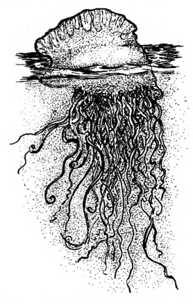

**Figure 4.10:** *Physalis* sp., Portuguese man o’ war

True jellyfish (*Scyphozoa*) are members of the *Cnidaria*, whose tentacles face down. They represent the medusa or free-swimming phase of *Scyphozoa*, preceding their polyp phase. *Ctenophora*, comb jellyfish, are colourless, oval blobs of jelly that float slowly. *Hydrozoa* are polyps which form fuzz-like colonies on rocks, after a brief phase as a free-swimming organism. This group includes fire corals, hydroids and siphonophores. Hydroids are feathery colonial organisms growing on the surface of coral.

Oceanic languages often distinguish several different kinds of jellyfish, including the spectacular Portugese man o’ war or bluebottle (*Physalia physalia*) but no POc terms for any jellyfish taxa are recoverable. Two PPn terms for jellyfish are reconstructable. One, referring to the Portuguese man o’war, is well supported and has a cognate in Bauan Fijian, where it refers to a hydroid.

| **PCP** |  | *bak(u)i | ‘k.o. jellyfish or hydroid’ |
| --- | --- | --- | --- |
| Fij | Bauan | *bakui* | ‘Hydra (colonial polyp)’ |
| **PPn** |  | *paki(paki) | ‘Portuguese man o’ war (bluebottle), *Physalia* sp.’ (pollex gives *paki) |
| Pn | Tongan | *peki-peki* | ‘bluebottle, stinging jellyfish’ |
| Pn | Niuean | *paki* | ‘Portuguese man o’war, *Physalis* sp.’ |
| Pn | East Uvean | *paki(a)* | ‘Portuguese man o’war, *Physalis* sp.’ |
| Pn | Hawaiian | *paki(malau)* | ‘Portuguese man o’war, *Physalis* sp.’ |
| Pn | Ifira-Mele | *paki-paki* | ‘jellyfish’ |
| Pn | Tikopia | *pakipaki* | ‘Portuguese man o’war, *Physalis* sp.’ |

| **PPn** |  | *kalukalu | ‘k.o. jellyfish’ |
| --- | --- | --- | --- |
| Pn | Tongan | *kolukalu* | ‘generic for certain kinds of jellyfish’ |
| Pn | Samoan | *ʔaluʔalu* | ‘k.o. edible jellyfish’ |
| Pn | Nanumean | *kalikali* | ‘jellyfish sp.’ |

cf. also:

| Pn | Rennellese | *kaŋukaŋu* | ‘an insect’ |
| --- | --- | --- | --- |
| Pn | Māori | *karukaru* | ‘spongy matter in a gourd, clotted blood, blood’ |

A PSES term for anemone, or possibly jellyfish, is reconstructable which may be cognate with PPn *mama ‘chiton’ (see §4.4).

| **PSES** |  | *mama | ‘k.o. anemone or jellyfish’ |
| --- | --- | --- | --- |
| SES | Gela | *mama(ndao)* | ‘sea creature, soft, no shell’ |
| SES | Arosi | *mama(nongi)* | ‘a sea anemone; eaten’ |
| SES | Lau | *mama-e-lade* | ‘small blue jellyfish on dead coral’ (Fox 1974) |
| SES | Lau | *mama-i-lade* | ‘sea anemone’ (Akimichi 1978) |

The following PCP term may have denoted a kind of hydrozoa but the diversity of vague glosses given to its reflexes makes this uncertain.

| **PCP** |  | *bulewa | ‘an organism growing on rocks, possibly encrusting brown rock coral’ |
| --- | --- | --- | --- |
| Fij | Bauan | *bulewa* | ‘k.o. coral, clinging to rocks, eaten by fish’ |
| Fij | Wayan | *bulewa* | ‘slimy brownish organism, growing on rocks and floating on sea, eaten by fish’ |
| **PPn** |  | *pulewa | ‘marine substance/creature with stone-like or rough exterior’ (pollex) |
| Pn | Kapingamarangi | *purewe* | (1) ‘sandpaper-like growth on coral’; (2) ‘coral variety’ |
| Pn | East Uvean | *puleva* | ‘k.o. sea cucumber’ |
| Pn | Mangareva | *pureva* | (1) ‘roe of fish’; (2) ‘yellow scum floating on the sea from about 17-21 Feb. Eaten by fish’ |
| Pn | Hawaiian | *pūlewa* | ‘k.o. stone, used as sinker’ |

## 7. Annelida: worms

Many annelid (segmented) worms live in tropical marine habitats. The two main groups are *Oligochaeta* (with few bristles) and *Polychaeta* (with many bristles). Marine worms are mainly *Polychaeta* and include fireworms, feather duster worms, sphagetti worms, Christmas tree worms and bobbit or palolo worms. Reconstructions are available for just two marine worm taxa.

### 7.1. *Sipunculus* sp., sandworm

| **POc** |  | *ibo | ‘k.o. sandworm, probably *Sipunculus* sp.’ |
| --- | --- | --- | --- |
| MM | Roviana | *ibo* | ‘small seaworm, much used for bait’ |
| Mic | Kiribatese | *ibo* | ‘a sandworm, *Sipunculus indicus*’ |
| Fij | Bauan | *ibo* | ‘large edible seaworm’ |
| Fij | Wayan | *ibo* | ‘k.o. sandworm, *Sipunculus* sp.’ |
| Pn | Samoan | *ipo* | ‘edible sandworm, *Sipunculus* sp.’ |
| Pn | Nanumean | *ipo* | ‘sp. of worm found on the beach’ |

cf. also:

| MM | Teop | *iobo* | ‘seaworms’ (*-o-* unexpected) |
| --- | --- | --- | --- |

Although this cognate set formally matches PMP *imbaw ‘marine mollusc sp.’ (Blust 1980b: 77) the latter reconstruction rests on cognates in two WMP languages which both refer to bivalves.

### 7.2. Fireworms (Polychaeta)

Fireworms, 5-18 cm long, bear many white bristles along their sides which can cause itching when touched. They bear a superficial resemblance to centipedes and millipedes. A well-supported PMP and POc reconstruction for ‘centipede’ exists, namely *qalipan, continued in PCP as *qaliva ‘millipede’. A separate term for ‘fireworm’, sometimes called ‘sea centipede’, is attributable to POc based on agreements between Saliba, a Papuan Tip language, and Polynesian witnesses. It appears that in PPn a single term, *weli, was applied both to fireworms and to centipedes and furry millipedes. Glosses given to cognates in North-Central Vanuatu and Southeast Solomonic suggest that this range of reference may well have existed in POc.

| **POc** |  | *weli | (1) ‘fireworm, sea centipede’; (2) ‘? k.o. millipede or centipede’ |
| --- | --- | --- | --- |
| PT | Sariba | *yeli-yeli* | ‘fireworm, *Pherecardia striata*’ |
| SES | Arosi | *weli* | ‘black thickbodied millipede, lulus sp, found on near the coast’ |
| SES | Arosi | *weri(marumu)* | ‘sp. of millipede with furry body’ |
| NCV | Raga | *weli, ueli* | ‘small iridescent centipede’ |
| NCV | Uripiv | *na-wel* | ‘palolo worm’ |
| **PPn** |  | *weli | (1) ‘centipede’; (2) ‘marine annelid like a centipede’ (cf. pollex) |
| Pn | East Futunan | *veli* | ‘a venomous creature found on the reef’ |
| Pn | Tongan | *veli* | ‘a hairy worm that lives mostly in water’ |
| Pn | Samoan | *veli* | ‘a fish that stings when touched’ |
| Pn | Pukapukan | *veli* | ‘a variety of sea centipede’ |
| Pn | Tikopia | *veri* | ‘marine animal on reef: long, segmented; stings painfully if trodden on’ |
| Pn | Mangareva | *veli* | ‘marine annelid like a centipede’ |
| Pn | Hawaiian | *weli* | ‘a holothurian’ |
| Pn | Māori | *weri* | ‘centipede’ |
| Pn | Tahitian | *veri* | ‘centipede’ |

cf. also:

| PT | Dobu | *pʷali-keke* | ‘millipede’ |
| --- | --- | --- | --- |
| PT | Molima | *pʷali-keke* | ‘poisonous millipede’ |
| SES | Lau | *fari-fari* | ‘scorpion’ |

### 7.3. Palolo worm (*Eunice viridis*, aka *Palola viridis*, *Leodis viridis*)

The palolo worm is distributed from Indonesia to the central Pacific. It burrows into coral. When spawning, the posterior end, filled with sperm and eggs, breaks off and swims to the surface. The annual spawning or ‘rise’, governed by the phase of the moon, occurs at regular times in the months October to December and at these times people scoop up the worms which are cooked and eaten.

A name for the palolo worm is attributable to PEOc, based on cognates shared by SES and NCV languages. The former reflect *odu, the latter *udu. The only known WOc cognate occurs in a Santa Isabel language, Maringe: *na-udu*, where *na-* reflects the POC common noun marker *na. The Maringe form may be a borrowing from a neighbouring SES language but it is noteworthy that its first vowel agrees with NCV rather than SES witnesses.

| MM | Maringe | *na-udu* | ‘*Leodis viridis*, palolo worm’ |
| --- | --- | --- | --- |

| **PEOc** |  | *(o,u)du | ‘*Leodis viridis*, palolo worm’ |
| --- | --- | --- | --- |
| **PSES** |  | *odu | ‘*Leodis viridis*, palolo worm’ |
| SES | Gela | *odu* |  |
| SES | Ghari | *odu* | ‘a worm that lives in coral’ |
| SES | Arosi | *ogu, oku* |  |
| SES | Lau | *ʔodu, ʔogu* |  |
| SES | Sa’a | *oku* |  |
| SES | ’Are’are | *ʔodu, ʔoku* |  |
| **PNCV** |  | *udu | ‘Eunice, palolo worm’ (Clark 2009) |
| NCV | Mota | *un* |  |
| NCV | Mwotlap | *n-in* |  |
| NCV | Raga | *udu* |  |
| NCV | Big Nambas | *n-ud* |  |
| NCV | Neve’ei | *nu-wud* |  |

A separate term is reconstructable for PCP, with reflexes in Fijian and Polynesian languages.

| **PCP** |  | *balolo | (1) ‘*Leodis viridis*, palolo worm’; (2) ‘name of the months when this worm rises’ |
| --- | --- | --- | --- |
| Fij | Bauan | *balolo* |  |
| Fij | Wayan | *balolo* |  |
| **PPn** |  | *palolo | (1) ‘palolo worm’; (2) ‘name of the months when this rises’ |
| Pn | Tongan | *palolo* |  |
| Pn | Samoan | *palolo* |  |
| Pn | East Uvean | *palolo* |  |
| Pn | Ifira-Mele | *paroro* | ‘red or green marine micro-organism with bad smell’ |

## 8. Poriphera: sponges

Sponges are conspicuous inhabitants of coral reefs. They come in a variety of shapes and sizes, attaching themselves wherever they can find a space. Some Oceanic languages have a general term for sponges, e.g. Lau *losi*, *lo-losi*, Gela *loi-losi*, Roviana *puha*, Dobuan *halu*, Motu *puta*, Sa’a *hulo*, but no widespread cognate sets have been noted, other than the following from Polynesian languages.

| **PPn** |  | *oma | ‘sponge’ |
| --- | --- | --- | --- |
| Pn | Tongan | *oma* |  |
| Pn | Niuean | *omo(mi)* |  |
| Pn | Samoan | *omo(mi)* |  |
| Pn | Tokelauan | *oma* |  |
| Pn | Marquesan | *oma-oma* | ‘k.o. jellyfish’ |

## 9. What proportion of POc taxa have been reconstructed?

Leaving aside the collective term *pinaŋoda, the number of fairly secure POc reconstructions for aquatic (including semi-aquatic) invertebrate taxa is 42, with a few additional tentative reconstructions at POc level and a number of other reconstructions attributable to PEOc or PWOc. Taking the Wayan figure of about 240 taxa as fairly typical of those Austronesian maritime communities which exploit fringing reefs and mangrove swamps, it follows that 42 is probably less than a fifth of the total number of aquatic taxa distinguished by POc speakers. The breakdown in Table 4.2, comparing Wayan with POc, indicates the distribution of the shortfalls across the main groups of aquatic invertebrates.

The relative paucity of POc reconstructions can be attributed in large part to gaps in the coverage provided by dictionaries of contemporary languages. Few dictionaries give anything like an exhaustive listing of terms for invertebrates. However, a pattern is discernable in the kinds of terms that can/cannot be reconstructed. One important category of terms almost completely missing from our reconstructions is binomials. A run through the list of reconstructions shows that all the POc terms are uninomials (unitary lexemes). By contrast, about a third of the Wayan names are binomials, including 40 of the 105 gastropod taxa, but only seven of the 35 bivalve taxa.

Why are uninomials more stable than binomials? Berlin (1992) argues that in folk taxonomies of wild animals and plants the most salient and well-marked categories for purposes of identification are folk generics (see ch. 8, §1.2.3). Names of taxa at the level of folk generic are usually uninominals (e.g. English *owl*, *whale*, *oak*, *willow*) or idioms, e.g. *blackbird*, *she-oak*, *pussy willow*). A folk generic may have a number of folk specifics, which are perceived as closely related but distinct types. These are typically known by binomials, made up of a folk generic plus a descriptive modifier which refers to one or another distinguishing feature of the taxon - its characteristic habitat, colour, size, shape, etc., e.g. *barn owl*, *grass owl*, *sooty owl*, *hump-backed whale*, *blue whale*. Folk generics commonly fall under high-order taxa, particularly the type that Berlin calls a life-form, such as English *fish*, *bird*, *snake*, and *tree*. Sometimes levels between life-form and folk generic are distinguished and Berlin calls these intermediates.

**Table 4.2** Terms for aquatic invertebrate groups known for Wayan and Proto Oceanic

|  | Wayan | POc |
| --- | --- | --- |
| **Crustaceans** |  |  |
| lobsters | 3 | 1 |
| prawns/shrimps | 7 | 1 |
| crabs (Brachyura) | 33 | 7 |
| crabs (Anomura) | 4 | 4 |
| Cirripedia | 1 | 0 |
| *subtotal* | 48 | 13 |
| **Molluscs** |  |  |
| gastropods | 105 | 7 |
| bivalves | 35 | 10 |
| chitons | 4 | 0 |
| cephalopods | 4 | 3 |
| *subtotal* | 148 | 20 |
| **Echinoderms** |  |  |
| sea cucumbers | 19 | 1 |
| sea urchins | 8 | 2 |
| starfish, brittle starfish | 4 | 1 |
| *subtotal* | 31 | 4 |
| **Cnidaria** |  |  |
| corals and anemones | 11 | 2 |
| jellyfish | 2 | 0 |
| subtotal | 13 | 2 |
| Worms | 5 |  |
| Total | 245 | 42 |

The POc terms for aquatic invertebrates that have survived are exclusively generics of some sort, either folk generics or high-order generics. The modifiers that distinguish folk specifics have not been stable. There are, perhaps, several reasons why modifiers are unstable. One is the variability of local species. Although the same orders, families and genera of common reef and shoreline animals are usually common to different regions of the tropical Pacific, the species are more variable from region to region. Migrants might be expected to apply new modifiers to newly encountered species if these were clearly distinct from those known in their former homeland. Another factor is the wide range of distinctive characteristics exhibited by certain species and genera of the same family, such as colour, shape, size and behaviour. Speakers can be expected from time to time to change the choice of the characteristic used to distinguish one taxon terminologically from its sister taxa. Finally, particular modifying terms may themselves be replaced by synonyms which come into favour, sometimes leading to loss or change of meaning in the original modifier.

Some groups of invertebrates show a much higher ratio of taxa reconstructed to POc level than others, when compared with Wayan totals. Among the crustaceans, the Anomura (hermit crabs) have a high ratio with 4/4, whereas the Brachyura (true crabs) score only 7/33. Prawns and shrimps score much lower (1/7), the sole POc term reconstructed being the generic for prawns and lobsters. Sea cucumbers and sea urchins also show a very low ratio: three POc reconstructions compared with 27 taxa distinguished in Wayan. The cephalopods (3/4) have by far the highest ratios among the molluscs. The bivalves (10/35) score much higher than the gastropods (7/105), a difference not solely attributable to the fact that binomials make up 40 of the 105 Wayan gastropod names but only 7 of the 35 bivalve names.

These ratios can be taken as a very rough measure of how persistent POc names have been for particular invertebrate groups: a high score for POc indicates a high retention rate of terms in daughter languages, a low score the converse. Very likely there is a correlation between how persistent a term is, and how salient or important the referent is to to members of the speech community. Of course, a creature can be salient for any of a number of reasons: economic importance, large size, unusual appearance, being dangerous, and so on. Closer study of such matters must be left for another occasion.

## Notes

[^1]: This is a much revised and expanded version of Pawley (1996). I am grateful to Meredith Osmond for help in compiling and checking the list of cognate sets, and to Ann Chowning. John Lynch and Malcolm Ross for valuable comments on a draft of the paper. I am also indebted to Ann Chowning for data on some New Britain languages, to Paul Geraghty for providing terms from the Viwa dialect of Wayan Fijian and for helpful discussion of the Wayan material and to John Lynch for comparative material on Southern Vanuatu languages.
[^2]: In these two reconstructions I have substituted *d for the POc phoneme that Clark writes as *nt.
[^3]: With respect to ‘shellfish’, much used in dictionary’ and wordlist glosses cited for this and certain other cognate sets, it should be noted that this term means different things to different people. Nearly all New Zealanders and many Australians and English people use ‘shellfish’ to mean ‘(edible) molluscs with external shells’, excluding crustaceans, whereas others, including most people from the USA, use it to mean ‘(edible) crustaceans and molluscs with external shells’. It is apparent that most of our sources for Oceanic languages use this term in the narrower sense.
[^4]: These numbers refer to terminal taxa, i.e. excluding higher-order taxa (generic terms with two or more subtaxa), and counting only one item for each set of synonyms or variant forms. Numbers are necessarily approximate because of disagreements among informants, the uncertain status of some descriptive binomials, and other factors.
[^5]: For information about taxonomies of aquatic invertebrates in particular Oceanic languages see Akimichi & Sakiyama (1991). Foale (1998), Hviding (2005). Pawley (1994).
[^6]: Blust (1980b) gives this form as PWMP but Oceanic cognates allow it to be attributed to PMP.